# Técnicas Multivariadas Aplicadas con R — Examen Parcial 2026-II

Flores Cueva Jose Armando

Carrasco Barrial Gian Piero

Barrientos Mauricio Fabricio Rodrigo

Puma Vilcahuaman Harly Steve

Evaristo Jacinto Gabriel Omar

Bautista Aldave Camila

Octubre de 2026

Universidad Nacional Agraria La Molina

Técnicas Multivariadas · Examen Parcial · Ciclo 2026-II

Técnicas multivariadas aplicadas con R

MANOVA factorial en DBCA, MANCOVA en DCA y en DBCA, regresión multivariada y análisis de componentes principales

P1 · MANOVA factorial en DBCAP2 · MANCOVA en DCAP3 · MANCOVA en DBCAP4 · Regresión multivariadaP5 · Componentes principales

Integrantes

Flores Cueva Jose Armando

Carrasco Barrial Gian Piero

Barrientos Mauricio Fabricio Rodrigo

Puma Vilcahuaman Harly Steve

Evaristo Jacinto Gabriel Omar

Bautista Aldave Camila

Docente: C. F. Miranda VillagómezLima, octubre de 2026

# Presentación del trabajo

Este documento reúne, en un solo informe reproducible, el desarrollo de las **cinco preguntas** del Examen Parcial 2026-II de Técnicas Multivariadas. Cada pregunta utiliza una base de datos distinta a las vistas en clase y se organiza según las pautas del examen: **data general, código R, introducción, desarrollo, discusión, conclusiones y bibliografía**.

| N.º | Técnica multivariada | Base de datos | Variables principales |
| --- | --- | --- | --- |
| **1** | MANOVA con experimento factorial en DBCA | `Datos_7_1_Caso.sav` — campaña de promoción de la cadena Mercanova (Aldás y Uriel, 2017) | Respuestas: ventas de cola y ron · Factores: semana × tipo de supermercado · Bloque: día |
| **2** | MANCOVA en DCA | `StudentsPerformance.csv` — 1000 estudiantes | Respuestas: lectura y escritura · Tratamiento: curso de preparación · Covariable: matemática |
| **3** | MANCOVA en DBCA | `Cuyes_MANCOVA_DBCA.xlsx` — 72 cuyes (base didáctica simulada) | Respuestas: ganancia de peso y rendimiento de carcasa · Tratamiento: dosis de probiótico · Bloque: lote · Covariables: peso y edad iniciales |
| **4** | Regresión multivariada | `state.x77` (incluida en R) — 50 estados de EE. UU. | Respuestas: esperanza de vida e ingreso · Predictoras: analfabetismo, graduados de secundaria y días de helada |
| **5** | Análisis de componentes principales | `Encuesta.xlsx` — 300 clientes de una cadena de supermercados | 8 variables de satisfacción (0–100) · Variable ilustrativa: cliente frecuente |

📂 Para compilar este documento

Guardar el archivo `.Rmd` en la **misma carpeta** que las bases `StudentsPerformance.csv`, `Cuyes_MANCOVA_DBCA.xlsx` y `Encuesta.xlsx`. La base de la pregunta 1 se descarga desde GitHub (si no hay internet, el código busca `Datos_7_1_Caso.sav` en la misma carpeta). Los paquetes de R faltantes se instalan automáticamente al compilar.

# 1 MANOVA con experimento factorial en DBCA

📋 Ficha de la pregunta

- **Técnica:** MANOVA con experimento factorial (semana × tipo de supermercado) en DBCA, con el día como bloque
- **Base de datos:** `Datos_7_1_Caso.sav` — campaña de promoción conjunta de Mercanova (Aldás y Uriel, 2017)
- **Variables respuesta:** ventas de cola y de ron
- **Factores:** semana (2 niveles) y tipo de supermercado (UC, UR y R) · **Bloque:** día de la semana (6 días)

## 1.1 Estructura del diseño

A continuación se analizará el siguiente experimento cuya estructura es la siguiente:

$$\mathbf{Y}_{ijk} = \boldsymbol{\mu} + \boldsymbol{\alpha}_i +
\boldsymbol{\beta}_j + \boldsymbol{\gamma}_k +
(\boldsymbol{\alpha\beta})_{ij} + \boldsymbol{\varepsilon}_{ijk}$$
$$i = 1,\dots,a, \qquad j = 1,\dots,b, \qquad k = 1,\dots,r$$
$$\boldsymbol{\varepsilon}_{ijk} \sim N_p(\mathbf{0}, \boldsymbol{\Sigma})$$
donde:

- $\mathbf{Y}_{ijk}$: vector de $p$ variables respuesta
- $\boldsymbol{\mu}$: media general
- $\boldsymbol{\alpha}_i$: efecto del nivel $i$ del factor A
- $\boldsymbol{\beta}_j$: efecto del nivel $j$ del factor B
- $\boldsymbol{\gamma}_k$: efecto del bloque $k$
- $(\boldsymbol{\alpha\beta})_{ij}$: efecto de la interacción A×B
- $\boldsymbol{\varepsilon}_{ijk}$: error experimental

### 1.1.1 Hipótesis

Para determinar si los factores A, B y los bloques tienen efecto o no sobre el vector de respuestas Y, las hipótesis nulas a formular son las siguientes:
$$H_0: \boldsymbol{\alpha}_i = \mathbf{0}$$

$$H_0: \boldsymbol{\beta}_j = \mathbf{0}$$

$$H_0: (\boldsymbol{\alpha\beta})_{ij} = \mathbf{0}$$

$$H_0: \boldsymbol{\gamma}_k = \mathbf{0}$$

### 1.1.2 Tabla de medias muestrales para cada combinación de los factores A y B

$$\begin{array}{c|cccc|c}
\hline
\text{Niveles del} & & \text{Niveles del factor B} & &
& \text{Marginal A} \\
\text{factor A} & 1 & 2 & \cdots & b & \\
\hline
1 & \bar{\mathbf{y}}_{11\bullet} & \bar{\mathbf{y}}_{12\bullet}
& \cdots & \bar{\mathbf{y}}_{1b\bullet} &
\bar{\mathbf{y}}_{1\bullet\bullet} \\
2 & \bar{\mathbf{y}}_{21\bullet} & \bar{\mathbf{y}}_{22\bullet}
& \cdots & \bar{\mathbf{y}}_{2b\bullet} &
\bar{\mathbf{y}}_{2\bullet\bullet} \\
\vdots & \vdots & \vdots & \ddots & \vdots & \vdots
\\
a & \bar{\mathbf{y}}_{a1\bullet} & \bar{\mathbf{y}}_{a2\bullet}
& \cdots & \bar{\mathbf{y}}_{ab\bullet} &
\bar{\mathbf{y}}_{a\bullet\bullet} \\
\hline
\text{Marginal B} & \bar{\mathbf{y}}_{\bullet 1\bullet} &
\bar{\mathbf{y}}_{\bullet 2\bullet} & \cdots &
\bar{\mathbf{y}}_{\bullet b\bullet} &
\bar{\mathbf{y}}_{\bullet\bullet\bullet} \\
\hline
\end{array}$$

$$\begin{array}{c|cccc|c}
\hline
\text{Bloque} & 1 & 2 & \cdots & r & \text{Media
general} \\
\hline
\text{Media del bloque} & \bar{\mathbf{y}}_{\bullet\bullet 1} &
\bar{\mathbf{y}}_{\bullet\bullet 2} & \cdots &
\bar{\mathbf{y}}_{\bullet\bullet r} &
\bar{\mathbf{y}}_{\bullet\bullet\bullet} \\
\hline
\end{array}$$

## 1.2 Datos a analizar

En este informe se utilizará un set de datos recopilado del libro de *Análisis multivariante aplicado con R* de Uriel, E. y Aldás, J. donde se realizó levemente un análisis multivariado factorial. Sin embargo, se buscará mejorar ese análisis añadiendo el factor bloque día al estudio como también realizar las pruebas de comparación correspondientes. El contexto del diseño va de la siguiente manera

> La cadena de supermercados Mercanova desea analizar los efectos de una campaña de promoción conjunta de dos productos: la bebida gaseosa Toca-cola y el ron Morenita. En la campaña de promoción, que ha tenido una duración de dos semanas, se ha llevado a cabo en todos los supermercados de la cadena una promoción de ventas basada en el “precio por paquete”, es decir, un precio inferior por la compra conjunta a lo que supondría la compra separada de los dos productos. La acción ha venido apoyada por degustaciones en el punto de venta. Atendiendo a las características de las zonas donde están enclavados, se han agrupado los 57 supermercados de la cadena en tres grupos: urbano comercial (UC), urbano residencial (UR) y rural (R). El potencial general de ventas de cada uno de estos grupos es muy similar. La campaña de promoción comenzó a finales de mes. Concretamente, la primera semana fue del lunes 24 al sábado 29 de octubre. La segunda semana estaba situada prácticamente en los primeros días de mes. (Aldás y Uriel, 2017, p. 252)

[figure not shown]

Se buscará responder las siguientes incógnitas en las conclusiones del análisis:

- ¿Han sido análogos los resultados de la campaña en los tres tipos de supermercado?
- ¿Es relevante la distinción entre semana fin de mes y semana principio de mes en la adquisición de productos de esta clase?
- ¿Existe interacción entre semana y tipo de supermercado?

Tabla 1. Datos sobre las ventas de dos productos de la cadena Mercanova

| Semana promoción Semana | Semana promoción Día | Urbano comercial Cola | Urbano comercial Ron | Urbano residencial Cola | Urbano residencial Ron | Rural Cola | Rural Ron | Totales Cola | Totales Ron | Medias Cola | Medias Ron |  |  |  |  |  |  |  |  |
| --- | --- | --- | --- | --- | --- | --- | --- | --- | --- | --- | --- | --- | --- | --- | --- | --- | --- | --- | --- |
| Primera | Lunes | 11 | 5 | 9 | 4 | 6 | 2 | 180 | 96 | 10 | 5.33 |  |  |  |  |  |  |  |  |
|  | Martes | 8 | 7 | 8 | 3 | 5 | 2 |  |  |  |  |  |  |  |  |  |  |  |  |
|  | Miércoles | 10 | 5 | 8 | 4 | 6 | 1 |  |  |  |  |  |  |  |  |  |  |  |  |
|  | Jueves | 14 | 6 | 9 | 6 | 7 | 4 |  |  |  |  |  |  |  |  |  |  |  |  |
|  | Viernes | 17 | 9 | 12 | 9 | 9 | 4 |  |  |  |  |  |  |  |  |  |  |  |  |
|  | Sábado | 18 | 10 | 14 | 10 | 9 | 5 |  |  |  |  |  |  |  |  |  |  |  |  |
| Segunda | Lunes | 17 | 7 | 8 | 10 | 6 | 2 |  |  |  |  | 252 | 156 | 14 | 8.67 |  |  |  |  |
|  | Martes | 19 | 10 | 10 | 8 | 7 | 7 |  |  |  |  |  |  |  |  |  |  |  |  |
|  | Miércoles | 22 | 9 | 12 | 6 | 10 | 6 |  |  |  |  |  |  |  |  |  |  |  |  |
|  | Jueves | 21 | 11 | 10 | 11 | 9 | 4 |  |  |  |  |  |  |  |  |  |  |  |  |
|  | Viernes | 23 | 14 | 15 | 12 | 10 | 5 |  |  |  |  |  |  |  |  |  |  |  |  |
|  | Sábado | 24 | 15 | 17 | 13 | 12 | 6 |  |  |  |  |  |  |  |  |  |  |  |  |
| Totales |  | 204 | 108 | 132 | 96 | 96 | 48 |  |  |  |  |  |  |  |  | 432 | 252 | – | – |
| Medias |  | 17 | 9 | 11 | 8 | 8 | 4 |  |  |  |  |  |  |  |  | – | – | 12 | 7 |

## 1.3 Pruebas de hipótesis

### 1.3.1 Prueba de normalidad multivariada

Con el propósito de evaluar el supuesto de normalidad multivariada se dividen los datos en grupos para aplicar el test multivariante de Shapiro.

```r
# Grupos por tipo de zona
grupoUC <- t(datos[datos$tipsuper == "UC", c("cola", "ron")])
grupoUR <- t(datos[datos$tipsuper == "UR", c("cola", "ron")])
grupoR  <- t(datos[datos$tipsuper == "R",  c("cola", "ron")])

# Grupos por semana
grupoSem1 <- t(datos[datos$semana == "Primera", c("cola", "ron")])
grupoSem2 <- t(datos[datos$semana == "Segunda", c("cola", "ron")])
```

Una vez realizado se procede a aplicar las pruebas por cada grupo

```r
mshapiro.test(grupoUC)
```

```
#>
#>  Shapiro-Wilk normality test
#>
#> data:  Z
#> W = 0.91279, p-value = 0.2316
```

```r
mshapiro.test(grupoUR)
```

```
#>
#>  Shapiro-Wilk normality test
#>
#> data:  Z
#> W = 0.88022, p-value = 0.08822
```

```r
mshapiro.test(grupoR)
```

```
#>
#>  Shapiro-Wilk normality test
#>
#> data:  Z
#> W = 0.78631, p-value = 0.006574
```

```r
mshapiro.test(grupoSem1)
```

```
#>
#>  Shapiro-Wilk normality test
#>
#> data:  Z
#> W = 0.96142, p-value = 0.6294
```

```r
mshapiro.test(grupoSem2)
```

```
#>
#>  Shapiro-Wilk normality test
#>
#> data:  Z
#> W = 0.94767, p-value = 0.3896
```

🔎 Interpretación

De estos resultados, no se rechaza la hipótesis de normalidad multivariada, a excepción de lo que ocurre con el grupo de zona Rural.

De forma adicional, se puede aplicar la prueba de normalidad multivariada a los residuos del modelo.

```r
mshapiro.test(t(residuals(fit)))
```

```
#>
#>  Shapiro-Wilk normality test
#>
#> data:  Z
#> W = 0.97285, p-value = 0.5083
```

🔎 Interpretación

A partir de esta prueba se puede concluir que efectivamente no se rechaza la hipótesis de normalidad multivariada

### 1.3.2 Prueba de homogeneidad de matrices de covarianza (Box’s M)

```r
# Igualdad de matrices de covarianzas (Box's M), una vez por factor
biotools::boxM(datos[, c("cola", "ron")], datos$semana)
```

```
#>
#>  Box's M-test for Homogeneity of Covariance Matrices
#>
#> data:  datos[, c("cola", "ron")]
#> Chi-Sq (approx.) = 10.094, df = 3, p-value = 0.01779
```

```r
biotools::boxM(datos[, c("cola", "ron")], datos$tipsuper)
```

```
#>
#>  Box's M-test for Homogeneity of Covariance Matrices
#>
#> data:  datos[, c("cola", "ron")]
#> Chi-Sq (approx.) = 13.049, df = 6, p-value = 0.04226
```

🔎 Interpretación

A partir de los valores obtenidos, se rechaza la homogeneidad de covarianzas al 5% de significancia, pero no al 1%. Al tener un diseño balanceado, se utilizará el estadístico de Pillai al ser más robusto a esta violación.

### 1.3.3 Prueba de esfericidad de Bartlett

Se requiere que las variables respuesta estén correlacionadas para justificar el uso de un análisis conjunto (MANOVA).

$$H_0: \mathbf{R}_p = \mathbf{I}$$
$$H_1: \mathbf{R}_p \neq
\mathbf{I}$$

```r
r_crudo <- cor(datos[, c("cola", "ron")])
cortest.bartlett(r_crudo, n = nrow(datos))
```

```
#> $chisq
#> [1] 34.76577
#>
#> $p.value
#> [1] 0.000000003718544
#>
#> $df
#> [1] 1
```

🔎 Interpretación

Con los datos originales, la prueba de Bartlett rechaza la hipótesis nula que la matriz de correlaciones sea la identidad. Por lo tanto, las ventas de cola y ron están correlacionadas y se realiza un análisis multivariado

```r
W  <- summary(fit)$SS$Residuals
gl <- df.residual(fit)

COV.W <- W / gl
R     <- cov2cor(COV.W)
R                               # matriz de correlaciones residuales
```

```
#>            cola        ron
#> cola 1.00000000 0.09990648
#> ron  0.09990648 1.00000000
```

```r
cortest.bartlett(R, n = gl)
```

```
#> $chisq
#> [1] 0.2257077
#>
#> $p.value
#> [1] 0.634725
#>
#> $df
#> [1] 1
```

🔎 Interpretación

Sin embargo, al calcular la correlación quitando los efectos de los bloques, factores e interacción llegando a la matriz residual, la prueba de bartlett no rechaza la hipótesis nula. Esto indica que la correlación antes vista se debe en gran parte a los efectos ya mencionados. Por criterio de los datos originales, se continuará el estudio considerando que se acepta el análisis multivariado.

## 1.4 Análisis de varianza multivariado (MANOVA)

```r
fit <- manova(cbind(cola, ron) ~ dia + semana * tipsuper, data = datos)
# Estadistico Wilks
summary(fit, test = "Wilks")
```

```
#>                 Df   Wilks approx F num Df den Df               Pr(>F)
#> dia              5 0.12711    8.663     10     48 0.000000068328819321 ***
#> semana           1 0.18634   52.398      2     24 0.000000001752794431 ***
#> tipsuper         2 0.04627   43.785      4     48 0.000000000000001912 ***
#> semana:tipsuper  2 0.36140    7.961      4     48 0.000052478875690333 ***
#> Residuals       25
#> ---
#> Signif. codes:  0 '***' 0.001 '**' 0.01 '*' 0.05 '.' 0.1 ' ' 1
```

```r
# Estadistico Pillai
summary(fit, test = "Pillai")
```

```
#>                 Df  Pillai approx F num Df den Df           Pr(>F)
#> dia              5 1.03434    5.356     10     50 0.00002451119319 ***
#> semana           1 0.81366   52.398      2     24 0.00000000175279 ***
#> tipsuper         2 1.32367   24.464      4     50 0.00000000002968 ***
#> semana:tipsuper  2 0.69757    6.695      4     50        0.0002142 ***
#> Residuals       25
#> ---
#> Signif. codes:  0 '***' 0.001 '**' 0.01 '*' 0.05 '.' 0.1 ' ' 1
```

```r
# Estadistico Hotelling
summary(fit, test = "Hotelling-Lawley")
```

```
#>                 Df Hotelling-Lawley approx F num Df den Df
#> dia              5           5.5973   12.874     10     46
#> semana           1           4.3665   52.398      2     24
#> tipsuper         2          12.6160   72.542      4     46
#> semana:tipsuper  2           1.6039    9.222      4     46
#> Residuals       25
#>                                Pr(>F)
#> dia                    0.000000000256 ***
#> semana                 0.000000001753 ***
#> tipsuper        < 0.00000000000000022 ***
#> semana:tipsuper        0.000014743140 ***
#> Residuals
#> ---
#> Signif. codes:  0 '***' 0.001 '**' 0.01 '*' 0.05 '.' 0.1 ' ' 1
```

```r
# Estadístico Roy
summary(fit, test = "Roy")
```

```
#>                 Df     Roy approx F num Df den Df              Pr(>F)
#> dia              5  5.3603   26.802      5     25 0.00000000273964006 ***
#> semana           1  4.3665   52.398      2     24 0.00000000175279443 ***
#> tipsuper         2 11.9468  149.335      2     25 0.00000000000001253 ***
#> semana:tipsuper  2  1.4947   18.684      2     25 0.00001089490503107 ***
#> Residuals       25
#> ---
#> Signif. codes:  0 '***' 0.001 '**' 0.01 '*' 0.05 '.' 0.1 ' ' 1
```

```r
# Manova univariado
summary.aov(fit)
```

```
#>  Response cola :
#>                 Df Sum Sq Mean Sq F value              Pr(>F)
#> dia              5 191.67  38.333  19.828 0.00000005619382768 ***
#> semana           1 144.00 144.000  74.483 0.00000000573619774 ***
#> tipsuper         2 504.00 252.000 130.345 0.00000000000005964 ***
#> semana:tipsuper  2  72.00  36.000  18.621 0.00001117532093453 ***
#> Residuals       25  48.33   1.933
#> ---
#> Signif. codes:  0 '***' 0.001 '**' 0.01 '*' 0.05 '.' 0.1 ' ' 1
#>
#>  Response ron :
#>                 Df  Sum Sq Mean Sq F value        Pr(>F)
#> dia              5 116.667  23.333 10.5422 0.00001572715 ***
#> semana           1 100.000 100.000 45.1807 0.00000048114 ***
#> tipsuper         2 168.000  84.000 37.9518 0.00000002663 ***
#> semana:tipsuper  2   8.000   4.000  1.8072        0.1849
#> Residuals       25  55.333   2.213
#> ---
#> Signif. codes:  0 '***' 0.001 '**' 0.01 '*' 0.05 '.' 0.1 ' ' 1
```

```r
# Matrices de suma de cuadrados y productos cruzados
summary(fit, intercept = TRUE)$SS
```

```
#> $`(Intercept)`
#>      cola  ron
#> cola 5184 3024
#> ron  3024 1764
#>
#> $dia
#>          cola      ron
#> cola 191.6667 137.8333
#> ron  137.8333 116.6667
#>
#> $semana
#>      cola ron
#> cola  144 120
#> ron   120 100
#>
#> $tipsuper
#>      cola ron
#> cola  504 252
#> ron   252 168
#>
#> $`semana:tipsuper`
#>      cola ron
#> cola   72  12
#> ron    12   8
#>
#> $Residuals
#>           cola       ron
#> cola 48.333333  5.166667
#> ron   5.166667 55.333333
```

🔎 Interpretación

Según los datos obtenidos, se puede apreciar que el efecto de la semana depende de la zona. Por consiguiente, los efectos principales de semana y zona no se leen por separado, sino de forma conjunta. De igual manera, el bloque (día) también es significativo, lo que nos indica que el bloqueo fue útil. Con $\boldsymbol{\alpha} = 0.05$ se rechazan las cuatro hipótesis nulas.

### 1.4.1 Bondad de ajuste

```r
# Matrices SCPC de cada efecto
Matrices <- summary(fit)$SS

FDia     <- Matrices$dia
FSemana  <- Matrices$semana
FZona    <- Matrices$tipsuper
FSemZona <- Matrices$`semana:tipsuper`
W        <- Matrices$Residuals

# Matriz SCPC total
T_total <- FDia + FSemana + FZona + FSemZona + W
T_total
```

```
#>      cola ron
#> cola  960 527
#> ron   527 448
```

```r
# Bondad de ajuste
eta2 <- 1 - det(FDia + W) / det(T_total)
eta2
```

```
#> [1] 0.8632697
```

🔎 Interpretación

El valor de $\eta^2$ de 0.8633 aprox nos indica que alrededor del 86% de la variabilidad multivariada total es explicada por los tratamientos.

### 1.4.2 Gráficos de interacción

Por consiguiente, se presentan los gráficos de interacción de tipo de zona y semana por cada variable respuesta.

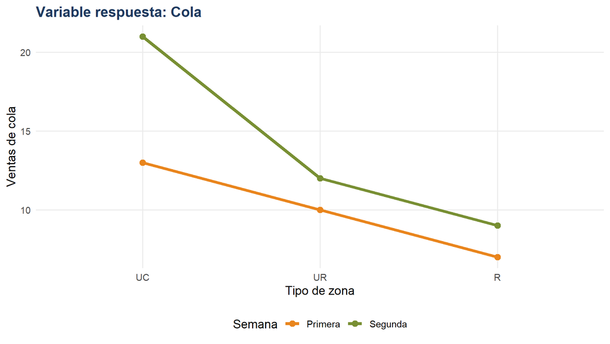

```r
medias <- aggregate(cbind(cola, ron) ~ semana + tipsuper, data = datos, FUN = mean)

ggplot(medias, aes(x = tipsuper, y = cola, group = semana, color = semana)) +
  geom_line(linewidth = 1.5) +
  geom_point(size = 2.5) +
  scale_color_met_d("Homer2") +
  labs(x = "Tipo de zona", y = "Ventas de cola", color = "Semana", title = "Variable respuesta: Cola")
```

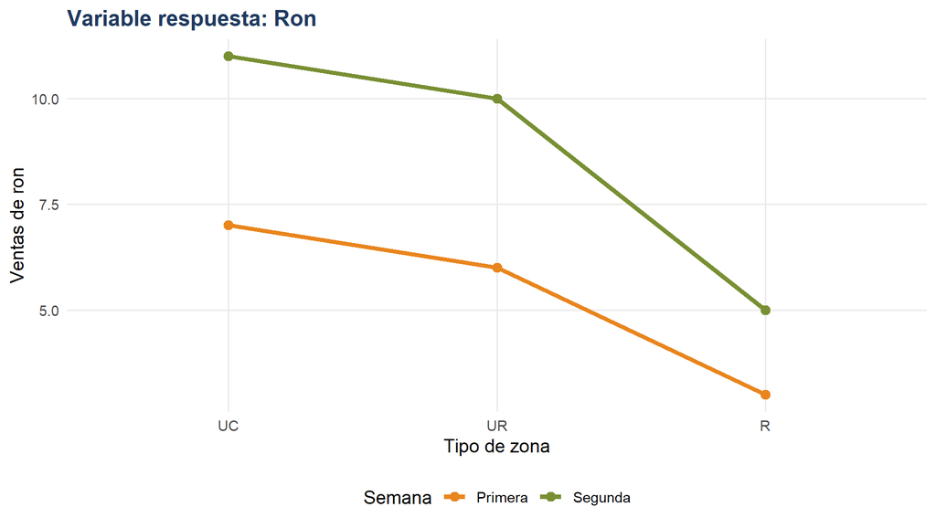

```r
ggplot(medias, aes(x = tipsuper, y = ron, group = semana, color = semana)) +
  geom_line(linewidth = 1.5) +
  geom_point(size = 2.5) +
  scale_color_met_d("Homer2") +
  labs(x = "Tipo de zona", y = "Ventas de ron", color = "Semana", title = "Variable respuesta: Ron")
```

🔎 Interpretación

Como se puede apreciar, en cuanto a las ventas de cola en la segunda semana son mayores al de la primera en los 3 tipos de zona, sin embargo la diferencia no es la misma. Las lineas no son paralelas por lo que se evidencia la interacción semana x zona. No obstante, en cuanto a las ventas de ron, la segunda semana supera a la primera semana pero la diferencia es similar en las tres zonas, por lo que la interacción es casi inexistente.

### 1.4.3 Análisis de efectos simples multivariados

```r
# Efecto de la semana dentro de cada zona
for (z in levels(datos$tipsuper)) {
  cat("\n--- Zona =", z, "---\n")
  print(summary(manova(cbind(cola, ron) ~ dia + semana,
                       data = subset(datos, tipsuper == z)), test = "Pillai"))
}
```

```
#>
#> --- Zona = UC ---
#>           Df  Pillai approx F num Df den Df   Pr(>F)
#> dia        5 1.40754    2.376     10     10 0.094257 .
#> semana     1 0.96629   57.333      2      4 0.001136 **
#> Residuals  5
#> ---
#> Signif. codes:  0 '***' 0.001 '**' 0.01 '*' 0.05 '.' 0.1 ' ' 1
#>
#> --- Zona = UR ---
#>           Df  Pillai approx F num Df den Df     Pr(>F)
#> dia        5 1.45420    2.664     10     10      0.069 .
#> semana     1 0.99257  267.130      2      4 0.00005522 ***
#> Residuals  5
#> ---
#> Signif. codes:  0 '***' 0.001 '**' 0.01 '*' 0.05 '.' 0.1 ' ' 1
#>
#> --- Zona = R ---
#>           Df  Pillai approx F num Df den Df  Pr(>F)
#> dia        5 1.28916   1.8136     10     10 0.18100
#> semana     1 0.70588   4.8000      2      4 0.08651 .
#> Residuals  5
#> ---
#> Signif. codes:  0 '***' 0.001 '**' 0.01 '*' 0.05 '.' 0.1 ' ' 1
```

🔎 Interpretación

A partir de estas pruebas se interpreta que la interacción observada en el MANOVA global ocurre por que el efecto de cambio de semana a semana se concentra más en las zonas Urbano Comercial y Urbano Residencial.

```r
# Efecto de la zona dentro de cada semana
for (s in levels(datos$semana)) {
  cat("\n--- Semana =", s, "---\n")
  print(summary(manova(cbind(cola, ron) ~ dia + tipsuper,
                       data = subset(datos, semana == s)), test = "Pillai"))
}
```

```
#>
#> --- Semana = Primera ---
#>           Df Pillai approx F num Df den Df   Pr(>F)
#> dia        5 1.0890   2.3907     10     20 0.046573 *
#> tipsuper   2 1.0741   5.8003      4     20 0.002881 **
#> Residuals 10
#> ---
#> Signif. codes:  0 '***' 0.001 '**' 0.01 '*' 0.05 '.' 0.1 ' ' 1
#>
#> --- Semana = Segunda ---
#>           Df Pillai approx F num Df den Df      Pr(>F)
#> dia        5 1.2155    3.099     10     20     0.01503 *
#> tipsuper   2 1.5071   15.290      4     20 0.000007048 ***
#> Residuals 10
#> ---
#> Signif. codes:  0 '***' 0.001 '**' 0.01 '*' 0.05 '.' 0.1 ' ' 1
```

🔎 Interpretación

Asimismo, se aprecia que en la primera semana hay evidencia de diferencia entre zonas, y esta diferencia aumenta marcadamente al pasar a la siguiente semana al comparar el efecto de las zonas dentro de cada semana.

### 1.4.4 Pruebas de comparación

```r
fit_lm <- lm(cbind(cola, ron) ~ dia + semana * tipsuper, data = datos)

# Semana dentro de cada zona
emm_sem <- emmeans(fit_lm, ~ semana | tipsuper | rep.meas)
mvcontrast(emm_sem, "pairwise", mult.name = "rep.meas", by = "tipsuper", adjust = "holm")
```

|  | contrast | tipsuper | T.square | df1 | df2 | F.ratio | p.value |
| --- | --- | --- | --- | --- | --- | --- | --- |
| 1 | Primera - Segunda | UC | 112.85053 | 2 | 24 | 54.168256 | 0.00000000126584 |
| 3 | Primera - Segunda | UR | 25.83325 | 2 | 24 | 12.399962 | 0.00020021891486 |
| 5 | Primera - Segunda | R | 10.57502 | 2 | 24 | 5.076008 | 0.01450570290753 |

```r
mvcontrast(emm_sem, "pairwise", mult.name = "rep.meas", by = "tipsuper", adjust = "none")
```

|  | contrast | tipsuper | T.square | df1 | df2 | F.ratio | p.value |
| --- | --- | --- | --- | --- | --- | --- | --- |
| 1 | Primera - Segunda | UC | 112.85053 | 2 | 24 | 54.168256 | 0.00000000126584 |
| 3 | Primera - Segunda | UR | 25.83325 | 2 | 24 | 12.399962 | 0.00020021891486 |
| 5 | Primera - Segunda | R | 10.57502 | 2 | 24 | 5.076008 | 0.01450570290753 |

🔎 Interpretación

A comparación del análisis de efectos simples anteriores, la diferencia entre semanas en la zona Rural si es significativa. Se rechaza $H_0$ en todos los contrastes. Esto se debe a que el análisis de efectos simples hechos por subconjunto usan solo 12 observaciones (error con 5 gl), mientras que emmeans usa el error del modelo completo (25 gl), que tiene más potencia.

```r
# Zona dentro de cada semana
emm_zona <- emmeans(fit_lm, ~ tipsuper | semana | rep.meas)
mvcontrast(emm_zona, "pairwise", mult.name = "rep.meas", by = "semana", adjust = "holm")
```

|  | contrast | semana | T.square | df1 | df2 | F.ratio | p.value |
| --- | --- | --- | --- | --- | --- | --- | --- |
| 1 | UC - UR | Primera | 14.59730 | 2 | 24 | 7.006704 | 0.004011375063040026 |
| 3 | UC - R | Primera | 71.30583 | 2 | 24 | 34.226796 | 0.000000280912231263 |
| 5 | UR - R | Primera | 23.79379 | 2 | 24 | 11.421018 | 0.000654539361313066 |
| 7 | UC - UR | Segunda | 125.69162 | 2 | 24 | 60.331980 | 0.000000000869442183 |
| 9 | UC - R | Segunda | 253.91370 | 2 | 24 | 121.878576 | 0.000000000000806795 |
| 11 | UR - R | Segunda | 43.94297 | 2 | 24 | 21.092626 | 0.000005168924735904 |

```r
mvcontrast(emm_zona, "pairwise", mult.name = "rep.meas", by = "semana", adjust = "none")
```

|  | contrast | semana | T.square | df1 | df2 | F.ratio | p.value |
| --- | --- | --- | --- | --- | --- | --- | --- |
| 1 | UC - UR | Primera | 14.59730 | 2 | 24 | 7.006704 | 0.0040113750630400256 |
| 3 | UC - R | Primera | 71.30583 | 2 | 24 | 34.226796 | 0.0000000936374104209 |
| 5 | UR - R | Primera | 23.79379 | 2 | 24 | 11.421018 | 0.0003272696806565329 |
| 7 | UC - UR | Segunda | 125.69162 | 2 | 24 | 60.331980 | 0.0000000004347210913 |
| 9 | UC - R | Segunda | 253.91370 | 2 | 24 | 121.878576 | 0.0000000000002689317 |
| 11 | UR - R | Segunda | 43.94297 | 2 | 24 | 21.092626 | 0.0000051689247359044 |

🔎 Interpretación

De igual forma, se aprecia una diferencia significativa entre las zonas por semana. Asimismo se evidencia que en la semana 2, las distancias multivariadas entre las 3 zonas aumentan notablemente.

## 1.5 Conclusiones

🏁 Conclusiones

Gracias al análisis multivariado se puede llegar a las siguientes conclusiones:

- Los resultados de las campañas difieren significativamente en los tres tipos de supermercado
- La distinción entre semana de fin de mes y semana de principio de mes también es significativa. Las ventas de principio de mes superan a las de fin de mes.
- La interacción semana x zona es significativa, asi que el efecto de cada factor depende el otro y no se interpretan por separado
- Aplicar el factor de bloqueo día ayudó a potenciar la precisión del análisis multivariado

## 1.6 Referencias

Aldás, J. y Uriel, E. (2017) Análisis multivariante aplicado con R (2da Edición). Ediciones Paraninfo.

# 2 MANCOVA en un diseño completamente al azar (DCA)

📋 Ficha de la pregunta

- **Técnica:** MANCOVA en DCA
- **Base de datos:** `StudentsPerformance.csv` — 1000 estudiantes
- **Tratamiento:** curso de preparación para el examen (`completed` / `none`)
- **Variables respuesta:** puntaje de lectura y puntaje de escritura
- **Covariable:** puntaje de matemáticas

## 2.1 Introducción

El **Análisis Multivariado de Covarianza (MANCOVA)** en un **Diseño Completamente al Azar (DCA)** permite evaluar el efecto de un tratamiento categórico sobre un conjunto de variables de respuesta continuas, controlando simultáneamente el efecto de una o más covariables continuas que influyen en las respuestas pero no son afectadas por el tratamiento.

En este estudio se evalúa el impacto del **Curso de Preparación para el Examen** (*test preparation course*, con niveles `completed` y `none`) sobre el rendimiento académico posterior en lenguaje:

- $Y_1$ **(Puntaje de Lectura — *reading score*):** nota en la prueba de lectura ($0 - 100$).
- $Y_2$ **(Puntaje de Escritura — *writing score*):** nota en la prueba de redacción ($0 - 100$).

Para aislar el sesgo derivado de la aptitud previa o habilidad académica general del alumno, se incluye como covariable:

- $X_1$ **(Puntaje de Matemáticas — *math score*):** nota cuantitativa en matemáticas ($0 - 100$).

El modelo es

$$\mathbf{y}_{ij}=\boldsymbol{\mu}+\boldsymbol{\tau}_i+\mathbf{B}^{\top}\left(x_{ij}-\bar{x}\right)+\boldsymbol{\varepsilon}_{ij},\qquad
\boldsymbol{\varepsilon}_{ij}\sim N_2(\mathbf{0},\boldsymbol{\Sigma}),$$

donde $\mathbf{y}_{ij}=(Y_1,Y_2)^\top$, $\boldsymbol{\tau}_i$ es el efecto del nivel $i$ del curso y $\mathbf{B}$ el vector de coeficientes de la covariable.

## 2.2 Carga y Preparación de Datos

```r
# Librerías requeridas
library(tidyverse)
library(mvnormtest)
library(heplots)
library(psych)
library(emmeans)
library(knitr)

# Carga de la base de datos
datos <- read.csv("StudentsPerformance.csv", stringsAsFactors = TRUE)

# Renombrar columnas para facilitar la sintaxis en R
colnames(datos) <- c("Gender", "Race_Ethnicity", "Parental_Education",
                     "Lunch", "Test_Prep", "Math_Score", "Reading_Score", "Writing_Score")

# Estructura del dataset
str(datos)
```

```
#> 'data.frame':    1000 obs. of  8 variables:
#>  $ Gender            : Factor w/ 2 levels "female","male": 1 1 1 2 2 1 1 2 2 1 ...
#>  $ Race_Ethnicity    : Factor w/ 5 levels "group A","group B",..: 2 3 2 1 3 2 2 2 4 2 ...
#>  $ Parental_Education: Factor w/ 6 levels "associate's degree",..: 2 5 4 1 5 1 5 5 3 3 ...
#>  $ Lunch             : Factor w/ 2 levels "free/reduced",..: 2 2 2 1 2 2 2 1 1 1 ...
#>  $ Test_Prep         : Factor w/ 2 levels "completed","none": 2 1 2 2 2 2 1 2 1 2 ...
#>  $ Math_Score        : int  72 69 90 47 76 71 88 40 64 38 ...
#>  $ Reading_Score     : int  72 90 95 57 78 83 95 43 64 60 ...
#>  $ Writing_Score     : int  74 88 93 44 75 78 92 39 67 50 ...
```

```r
head(datos, 10) %>% kable(caption = "Primeros 10 registros del dataset de rendimiento escolar")
```

Primeros 10 registros del dataset de rendimiento escolar

| Gender | Race_Ethnicity | Parental_Education | Lunch | Test_Prep | Math_Score | Reading_Score | Writing_Score |
| --- | --- | --- | --- | --- | --- | --- | --- |
| female | group B | bachelor’s degree | standard | none | 72 | 72 | 74 |
| female | group C | some college | standard | completed | 69 | 90 | 88 |
| female | group B | master’s degree | standard | none | 90 | 95 | 93 |
| male | group A | associate’s degree | free/reduced | none | 47 | 57 | 44 |
| male | group C | some college | standard | none | 76 | 78 | 75 |
| female | group B | associate’s degree | standard | none | 71 | 83 | 78 |
| female | group B | some college | standard | completed | 88 | 95 | 92 |
| male | group B | some college | free/reduced | none | 40 | 43 | 39 |
| male | group D | high school | free/reduced | completed | 64 | 64 | 67 |
| female | group B | high school | free/reduced | none | 38 | 60 | 50 |

## 2.3 Verificación de Supuestos Estadísticos

### 2.3.1 Normalidad Multivariada por Grupo

🎯 Hipótesis

$H_0$: el vector $(Y_1, Y_2)$ sigue una distribución normal bivariada en cada nivel de `Test_Prep`, frente a $H_1$: no la sigue. No se rechaza $H_0$ si $p \geq 0.05$.

```r
grupos <- levels(datos$Test_Prep)

for (g in grupos) {
  sub_data <- datos %>%
    filter(Test_Prep == g) %>%
    dplyr::select(Reading_Score, Writing_Score)

  test <- mshapiro.test(t(sub_data))
  cat("Tratamiento (Test_Prep):", g, "| p-valor Shapiro-Wilk Multivariado:", round(test$p.value, 6), "\n")
}
```

```
#> Tratamiento (Test_Prep): completed | p-valor Shapiro-Wilk Multivariado: 0.170488
#> Tratamiento (Test_Prep): none | p-valor Shapiro-Wilk Multivariado: 0.066581
```

### 2.3.2 Homogeneidad de Matrices de Varianza-Covarianza

🎯 Hipótesis

$H_0:\ \boldsymbol{\Sigma}_{completed}=\boldsymbol{\Sigma}_{none}$ frente a $H_1$: las matrices de covarianza difieren entre los dos niveles del curso.

```r
res_boxm <- heplots::boxM(cbind(Reading_Score, Writing_Score) ~ Test_Prep, data = datos)
summary(res_boxm)
```

```
#>
#>  Box's M-test for Homogeneity of Covariance Matrices
#>
#> data:  datos
#>
#> Chi-Sq (approx.) =  11.35977
#> df:   3
#> p-value: 0.0099
#>
#> log of Covariance determinants:
#> completed      none    pooled
#>    8.1453    8.2744    8.2396
#>
#> Eigenvalues:
#>   completed     none   pooled
#> 1  355.2004 424.9643 399.9362
#> 2    9.7047   9.2295   9.4719
#>
#> Statistics based on eigenvalues:
#>           completed      none    pooled
#> product   3447.1265 3922.2211 3788.1627
#> sum        364.9051  434.1938  409.4082
#> precision    9.4466    9.0333    9.2528
#> max        355.2004  424.9643  399.9362
```

### 2.3.3 Correlación entre Variables Dependientes (Prueba de Esfericidad de Bartlett)

🎯 Hipótesis

$H_0:\ \mathbf{R}=\mathbf{I}$ (las respuestas no están correlacionadas) frente a $H_1:\ \mathbf{R}\neq\mathbf{I}$. Si se rechaza $H_0$, se justifica el análisis conjunto.

```r
Y_mat <- datos %>% dplyr::select(Reading_Score, Writing_Score)
cortest.bartlett(cor(Y_mat), n = nrow(Y_mat))
```

```
#> $chisq
#> [1] 2415.961
#>
#> $p.value
#> [1] 0
#>
#> $df
#> [1] 1
```

## 2.4 Desarrollo del Modelo MANCOVA en DCA

🎯 Hipótesis

- **Tratamiento:** $H_0:\ \boldsymbol{\tau}_{completed}=\boldsymbol{\tau}_{none}=\mathbf{0}$ (los vectores de medias ajustadas por `Math_Score` son iguales) frente a $H_1$: al menos un $\boldsymbol{\tau}_i\neq\mathbf{0}$.
- **Covariable:** $H_0:\ \mathbf{B}=\mathbf{0}$ (la matemática no explica lectura ni escritura) frente a $H_1:\ \mathbf{B}\neq\mathbf{0}$.

```r
modelo_mancova <- manova(
  cbind(Reading_Score, Writing_Score) ~ Test_Prep + Math_Score,
  data = datos
)

# Estadísticos de contraste multivariado
summary(modelo_mancova, test = "Pillai")
```

```
#>             Df  Pillai approx F num Df den Df                Pr(>F)
#> Test_Prep    1 0.23716   154.82      2    996 < 0.00000000000000022 ***
#> Math_Score   1 0.66531   989.93      2    996 < 0.00000000000000022 ***
#> Residuals  997
#> ---
#> Signif. codes:  0 '***' 0.001 '**' 0.01 '*' 0.05 '.' 0.1 ' ' 1
```

```r
summary(modelo_mancova, test = "Wilks")
```

```
#>             Df   Wilks approx F num Df den Df                Pr(>F)
#> Test_Prep    1 0.76284   154.82      2    996 < 0.00000000000000022 ***
#> Math_Score   1 0.33469   989.93      2    996 < 0.00000000000000022 ***
#> Residuals  997
#> ---
#> Signif. codes:  0 '***' 0.001 '**' 0.01 '*' 0.05 '.' 0.1 ' ' 1
```

```r
summary(modelo_mancova, test = "Hotelling-Lawley")
```

```
#>             Df Hotelling-Lawley approx F num Df den Df                Pr(>F)
#> Test_Prep    1          0.31089   154.82      2    996 < 0.00000000000000022
#> Math_Score   1          1.98782   989.93      2    996 < 0.00000000000000022
#> Residuals  997
#>
#> Test_Prep  ***
#> Math_Score ***
#> Residuals
#> ---
#> Signif. codes:  0 '***' 0.001 '**' 0.01 '*' 0.05 '.' 0.1 ' ' 1
```

```r
summary(modelo_mancova, test = "Roy")
```

```
#>             Df     Roy approx F num Df den Df                Pr(>F)
#> Test_Prep    1 0.31089   154.82      2    996 < 0.00000000000000022 ***
#> Math_Score   1 1.98782   989.93      2    996 < 0.00000000000000022 ***
#> Residuals  997
#> ---
#> Signif. codes:  0 '***' 0.001 '**' 0.01 '*' 0.05 '.' 0.1 ' ' 1
```

### 2.4.1 Evaluación Univariada (ANCOVA por Variable Respuesta)

```r
summary.aov(modelo_mancova)
```

```
#>  Response Reading_Score :
#>              Df Sum Sq Mean Sq F value                Pr(>F)
#> Test_Prep     1  12449   12449  181.03 < 0.00000000000000022 ***
#> Math_Score    1 131944  131944 1918.74 < 0.00000000000000022 ***
#> Residuals   997  68560      69
#> ---
#> Signif. codes:  0 '***' 0.001 '**' 0.01 '*' 0.05 '.' 0.1 ' ' 1
#>
#>  Response Writing_Score :
#>              Df Sum Sq Mean Sq F value                Pr(>F)
#> Test_Prep     1  22591   22591  299.69 < 0.00000000000000022 ***
#> Math_Score    1 132928  132928 1763.35 < 0.00000000000000022 ***
#> Residuals   997  75158      75
#> ---
#> Signif. codes:  0 '***' 0.001 '**' 0.01 '*' 0.05 '.' 0.1 ' ' 1
```

## 2.5 Comparaciones Múltiples de Medias Ajustadas

🎯 Hipótesis

$H_0:\ \boldsymbol{\mu}^{aj}_{i}=\boldsymbol{\mu}^{aj}_{i'}$ frente a $H_1:\ \boldsymbol{\mu}^{aj}_{i}\neq\boldsymbol{\mu}^{aj}_{i'}$, con el contraste $T^2$ de Hotelling y ajuste de Bonferroni.

```r
fit_lm <- lm(
  cbind(Reading_Score, Writing_Score) ~ Test_Prep + Math_Score,
  data = datos
)

emm <- emmeans(fit_lm, ~ Test_Prep | rep.meas)
emm
```

```
#> rep.meas = Reading_Score:
#>  Test_Prep emmean    SE  df lower.CL upper.CL
#>  completed   71.1 0.443 997     70.2     72.0
#>  none        68.1 0.329 997     67.4     68.7
#>
#> rep.meas = Writing_Score:
#>  Test_Prep emmean    SE  df lower.CL upper.CL
#>  completed   71.6 0.464 997     70.7     72.5
#>  none        66.1 0.345 997     65.4     66.7
#>
#> Confidence level used: 0.95
```

```r
# Comparación por pares multivariada basada en la distribución de Hotelling
mvcontrast(emm, method = 'pairwise', mult.name = 'rep.meas', adjust = 'bonferroni')
```

|  | contrast | T.square | df1 | df2 | F.ratio | p.value |
| --- | --- | --- | --- | --- | --- | --- |
| 1 | completed - none | 125.0735 | 2 | 996 | 62.47402 | 0.0000000000000000000000000275156 |

## 2.6 Discusión

💬 Discusión

**Efecto de la covariable:** la covariable `Math_Score` resultó altamente significativa ($p < 0.001$), lo que demuestra que la habilidad previa en matemáticas explica una proporción sustancial de la variabilidad en los puntajes de lectura y escritura. Esto valida la elección de un MANCOVA sobre un MANOVA simple.

**Efecto del tratamiento:** las cuatro pruebas multivariadas (Pillai, Wilks, Hotelling-Lawley y Roy) fueron altamente significativas ($p < 0.001$), lo que indica que el hábito de completar el curso de preparación modifica significativamente el vector de medias multivariadas de lectura y escritura.

**Ajuste de medias:** al realizar las comparaciones *post-hoc* sobre las medias ajustadas por la covariable, se evidencia que los estudiantes que completaron el curso obtienen rendimientos promedio superiores en ambas competencias de lenguaje.

## 2.7 Conclusiones

🏁 Conclusiones

Se justificó estadísticamente la aplicación del modelo MANCOVA en DCA dada la alta correlación entre las competencias de lenguaje ($r = 0.955$) y la relevancia de la covariable matemática ($p < 0.001$).

Completar el curso de preparación (`completed`) incrementa de forma estadísticamente significativa el desempeño combinado en lectura y redacción, incluso al igualar a los alumnos en su nivel inicial de razonamiento matemático.

El uso de la covariable permitió remover la varianza no controlada, incrementando la precisión y la potencia del contraste del diseño DCA.

## 2.8 Bibliografía

- Hair, J. F., Black, W. C., Babin, B. J., & Anderson, R. E. (2019). *Multivariate Data Analysis* (8th ed.). Cengage Learning.
- Miranda Villagómez, C. F. (2026). *Notas de clase: MANOVA y MANCOVA en Diseños Experimentales*. Universidad Nacional Agraria La Molina.
- R Core Team (2026). *R: A language and environment for statistical computing*. R Foundation for Statistical Computing, Vienna, Austria.

# 3 MANCOVA en un diseño en bloques completos al azar (DBCA)

📋 Ficha de la pregunta

- **Técnica:** MANCOVA en DBCA
- **Caso:** efecto de la dosis de probiótico sobre el crecimiento y la calidad de carcasa de cuyes
- **Base de datos:** `Cuyes_MANCOVA_DBCA.xlsx` — 72 cuyes (base didáctica simulada)
- **Tratamiento / bloque:** dosis de probiótico (0, 1, 2 y 3 g/kg) / lote (6 bloques)
- **Respuestas / covariables:** ganancia de peso y rendimiento de carcasa / peso inicial y edad inicial

## 3.1 Introducción y planteamiento del caso

### 3.1.1 Problema experimental

La crianza de **cuyes** (*Cavia porcellus*) es una actividad pecuaria clave en la sierra y costa del Perú. Los productores buscan **mejorar el crecimiento sin deteriorar la calidad de la carcasa**, y una alternativa estudiada es incorporar **probióticos** (*Lactobacillus* + *Saccharomyces*) en el alimento. Se evaluaron cuatro dosis en un experimento de engorde de 8 semanas.

Un análisis univariado (un ANOVA por variable) sería insuficiente porque:

- la **ganancia de peso** y el **rendimiento de carcasa** son variables **correlacionadas**, así que analizarlas por separado ignora su estructura conjunta e infla el error tipo I global;
- los animales **no partieron en igualdad de condiciones**: difieren en **peso inicial** y **edad inicial**, y esa variabilidad puede enmascarar (o simular) el efecto del probiótico;
- los animales se agruparon en **lotes por peso al destete**, fuente de variación que el diseño debe controlar.

Por ello se usa un **MANCOVA en DBCA**: compara el *vector* de medias de las respuestas entre dosis, **ajustado por covariables** y **controlando el efecto del bloque**.

📌 Estructura del diseño

- **Diseño:** DBCA con 6 bloques (lotes), 4 tratamientos y 3 cuyes por combinación bloque × tratamiento ($n = 72$).
- **Factor (tratamiento):** `Probiotico` = 0, 1, 2 y 3 g/kg de alimento (0 g/kg = control).
- **Bloque:** `Bloque` = Lote1 … Lote6, formados por peso vivo al destete.
- **Variables respuesta** $\mathbf{y}$: `Ganancia_peso` (g) y `Rend_carcasa` (%).
- **Covariables** $\mathbf{x}$: `Peso_ini` (g) y `Edad_ini` (días), medidas **antes** de aplicar el tratamiento.

### 3.1.2 Modelo estadístico

Para el animal $k$ del bloque $j$ que recibe la dosis $i$ ($i=1,\dots,4$; $j=1,\dots,6$; $k=1,2,3$):

$$\underbrace{\mathbf{y}_{ijk}}_{2\times
1}=\boldsymbol{\mu}+\boldsymbol{\tau}_i+\boldsymbol{\beta}_j+\mathbf{B}^{\top}\left(\mathbf{x}_{ijk}-\bar{\mathbf{x}}\right)+\boldsymbol{\varepsilon}_{ijk},\qquad
\boldsymbol{\varepsilon}_{ijk}\sim N_2(\mathbf{0},\boldsymbol{\Sigma})$$

donde:

| Símbolo | Significado |
| --- | --- |
| $\mathbf{y}_{ijk}=(\text{Ganancia}, \text{Rendimiento})^\top$ | vector de respuestas |
| $\boldsymbol{\mu}$ | vector de medias generales |
| $\boldsymbol{\tau}_i$ | efecto (vectorial) de la dosis $i$, con $\sum_i \boldsymbol{\tau}_i=\mathbf{0}$ |
| $\boldsymbol{\beta}_j$ | efecto (vectorial) del bloque $j$, con $\sum_j \boldsymbol{\beta}_j=\mathbf{0}$ |
| $\mathbf{x}_{ijk}=(\text{Peso\_ini},\text{Edad\_ini})^\top$ | vector de covariables y $\bar{\mathbf{x}}$ su media |
| $\mathbf{B}$ ($2\times2$) | matriz de coeficientes de regresión **común** a todos los tratamientos (supuesto de pendientes homogéneas) |
| $\boldsymbol{\varepsilon}_{ijk}$ | error aleatorio, $N_2(\mathbf 0,\boldsymbol\Sigma)$, independiente entre animales |

En forma matricial global: $\mathbf{Y}=\mathbf{X}\boldsymbol{\Gamma}+\mathbf{E}$, con $\mathbf{X}$ la matriz de diseño (constante + covariables + variables indicadoras de bloque y tratamiento).

### 3.1.3 Hipótesis a contrastar

🎯 Hipótesis principal (efecto del probiótico, ajustado por covariables y bloque)

$$H_0:\
\boldsymbol{\tau}_1=\boldsymbol{\tau}_2=\boldsymbol{\tau}_3=\boldsymbol{\tau}_4=\mathbf{0}\qquad\text{vs}\qquad
H_1:\ \text{al menos un }\boldsymbol{\tau}_i\neq\mathbf{0}$$

Equivalentemente, $H_0$: los **vectores de medias ajustadas** $\boldsymbol{\mu}_i^{aj}=(\mu^{aj}_{i,\text{Ganancia}},\mu^{aj}_{i,\text{Rend}})^\top$ son iguales en las 4 dosis.

**Hipótesis auxiliares**

- **Covariables:** $H_0:\ \mathbf{B}=\mathbf{0}$ (las covariables no explican las respuestas) vs $H_1:\ \mathbf{B}\neq\mathbf{0}$.
- **Bloques:** $H_0:\ \boldsymbol{\beta}_1=\dots=\boldsymbol{\beta}_6=\mathbf{0}$ vs $H_1$: algún $\boldsymbol{\beta}_j\neq\mathbf{0}$.

**Estadístico base:** con $\mathbf{H}$ = matriz de sumas de cuadrados y productos cruzados (SCPC) del efecto y $\mathbf{E}$ = SCPC del error, se usan las raíces características $\lambda_1\ge\lambda_2$ de $\mathbf{E}^{-1}\mathbf{H}$:

$$\Lambda=\frac{|\mathbf{E}|}{|\mathbf{E}+\mathbf{H}|}=\prod_{k}\frac{1}{1+\lambda_k},\quad
V=\sum_k\frac{\lambda_k}{1+\lambda_k},\quad
T^2_{HL}=\sum_k\lambda_k,\quad
\theta=\frac{\lambda_1}{1+\lambda_1}$$

(Wilks, Pillai, Hotelling-Lawley y Roy, respectivamente). Nivel de significación: $\alpha=0.05$.

## 3.2 Base de datos y exploración previa

### 3.2.1 Origen y estructura

La base `Cuyes_MANCOVA_DBCA.xlsx` es **didáctica y reproducible**: se generó por simulación (semilla 2026) a partir de un modelo lineal aditivo con error normal bivariado, tomando como referencia magnitudes zootécnicas razonables para cuyes de engorde. **No proviene de un experimento real** (se declara así para fines académicos). Contiene tres hojas: `Contexto`, `Datos` y `Diccionario`.

```r
datos <- read_excel("Cuyes_MANCOVA_DBCA.xlsx", sheet = "Datos") %>%
  mutate(Bloque = factor(Bloque),
         Probiotico = factor(Probiotico, levels = c("0 g/kg", "1 g/kg", "2 g/kg", "3 g/kg"))) %>%
  as.data.frame()

Y <- c("Ganancia_peso", "Rend_carcasa")   # respuestas
X <- c("Peso_ini", "Edad_ini")            # covariables

str(datos)
```

```
#> 'data.frame':    72 obs. of  7 variables:
#>  $ Cuy          : chr  "C01" "C02" "C03" "C04" ...
#>  $ Bloque       : Factor w/ 6 levels "Lote1","Lote2",..: 1 1 1 1 1 1 1 1 1 1 ...
#>  $ Probiotico   : Factor w/ 4 levels "0 g/kg","1 g/kg",..: 1 2 2 4 1 3 1 3 4 4 ...
#>  $ Peso_ini     : num  264 269 261 274 284 ...
#>  $ Edad_ini     : num  21 21 22 20 20 25 22 21 23 20 ...
#>  $ Ganancia_peso: num  601 627 628 662 629 ...
#>  $ Rend_carcasa : num  66.8 66.7 66.2 68.8 67.3 ...
```

```r
head(datos, 10) %>% tabla("Primeras 10 observaciones")
```

Primeras 10 observaciones

| Cuy | Bloque | Probiotico | Peso_ini | Edad_ini | Ganancia_peso | Rend_carcasa |
| --- | --- | --- | --- | --- | --- | --- |
| C01 | Lote1 | 0 g/kg | 264.1 | 21 | 601.3 | 66.84 |
| C02 | Lote1 | 1 g/kg | 268.6 | 21 | 627.4 | 66.69 |
| C03 | Lote1 | 1 g/kg | 261.1 | 22 | 627.9 | 66.25 |
| C04 | Lote1 | 3 g/kg | 274.5 | 20 | 661.6 | 68.78 |
| C05 | Lote1 | 0 g/kg | 284.0 | 20 | 629.2 | 67.31 |
| C06 | Lote1 | 2 g/kg | 284.1 | 25 | 659.9 | 69.18 |
| C07 | Lote1 | 0 g/kg | 252.6 | 22 | 647.5 | 68.42 |
| C08 | Lote1 | 2 g/kg | 242.9 | 21 | 661.9 | 68.85 |
| C09 | Lote1 | 3 g/kg | 283.1 | 23 | 598.5 | 66.19 |
| C10 | Lote1 | 3 g/kg | 258.6 | 20 | 628.6 | 67.71 |

```r
as.data.frame.matrix(table(datos$Bloque, datos$Probiotico)) %>%
  tabla("Réplicas por bloque × dosis (diseño balanceado)")
```

Réplicas por bloque × dosis (diseño balanceado)

|  | 0 g/kg | 1 g/kg | 2 g/kg | 3 g/kg |
| --- | --- | --- | --- | --- |
| Lote1 | 3 | 3 | 3 | 3 |
| Lote2 | 3 | 3 | 3 | 3 |
| Lote3 | 3 | 3 | 3 | 3 |
| Lote4 | 3 | 3 | 3 | 3 |
| Lote5 | 3 | 3 | 3 | 3 |
| Lote6 | 3 | 3 | 3 | 3 |

El diseño es **balanceado** (3 cuyes por celda), lo que garantiza ortogonalidad entre bloques y tratamientos, y datos completos (72 de 72 filas sin valores perdidos).

### 3.2.2 Vectores de medias y matrices de covarianza

```r
datos %>%
  group_by(Probiotico) %>%
  summarise(n = n(),
            across(all_of(c(X, Y)), list(media = mean, de = sd), .names = "{.col}_{.fn}")) %>%
  tabla("Medias y desviaciones estándar por dosis de probiótico (sin ajustar)", digits = 2)
```

Medias y desviaciones estándar por dosis de probiótico (sin ajustar)

| Probiotico | n | Peso_ini_media | Peso_ini_de | Edad_ini_media | Edad_ini_de | Ganancia_peso_media | Ganancia_peso_de | Rend_carcasa_media | Rend_carcasa_de |
| --- | --- | --- | --- | --- | --- | --- | --- | --- | --- |
| 0 g/kg | 18 | 284.9 | 29.21 | 22.11 | 1.88 | 633.5 | 22.56 | 67.32 | 0.65 |
| 1 g/kg | 18 | 285.8 | 27.10 | 21.39 | 2.87 | 656.8 | 23.73 | 67.77 | 0.96 |
| 2 g/kg | 18 | 289.1 | 21.44 | 21.28 | 2.02 | 681.5 | 24.19 | 68.71 | 0.72 |
| 3 g/kg | 18 | 289.9 | 35.87 | 21.33 | 2.22 | 660.3 | 25.86 | 68.15 | 1.18 |

```r
datos %>%
  group_by(Bloque) %>%
  summarise(n = n(), across(all_of(c(X, Y)), mean)) %>%
  tabla("Vector de medias por bloque", digits = 2)
```

Vector de medias por bloque

| Bloque | n | Peso_ini | Edad_ini | Ganancia_peso | Rend_carcasa |
| --- | --- | --- | --- | --- | --- |
| Lote1 | 12 | 268.4 | 21.75 | 636.7 | 67.68 |
| Lote2 | 12 | 275.7 | 21.17 | 643.1 | 67.45 |
| Lote3 | 12 | 288.0 | 21.25 | 664.9 | 68.13 |
| Lote4 | 12 | 287.6 | 21.75 | 654.1 | 67.97 |
| Lote5 | 12 | 294.9 | 21.50 | 672.2 | 68.41 |
| Lote6 | 12 | 310.0 | 21.75 | 677.1 | 68.29 |

```r
cat("**Matriz de covarianza de las respuestas por dosis**\n\n")
```

**Matriz de covarianza de las respuestas por dosis**

```r
for (g in levels(datos$Probiotico)) {
  cat("\n\n*Dosis ", g, "*\n\n", sep = "")
  print(kable(cov(datos[datos$Probiotico == g, Y]), digits = 3, align = "c") %>%
          kable_styling(full_width = FALSE, bootstrap_options = c("striped", "condensed")))
}
```

*Dosis 0 g/kg*

|  | Ganancia_peso | Rend_carcasa |
| --- | --- | --- |
| Ganancia_peso | 509.066 | 7.052 |
| Rend_carcasa | 7.052 | 0.421 |

*Dosis 1 g/kg*

|  | Ganancia_peso | Rend_carcasa |
| --- | --- | --- |
| Ganancia_peso | 563.33 | 15.43 |
| Rend_carcasa | 15.43 | 0.92 |

*Dosis 2 g/kg*

|  | Ganancia_peso | Rend_carcasa |
| --- | --- | --- |
| Ganancia_peso | 585.346 | 1.907 |
| Rend_carcasa | 1.907 | 0.521 |

*Dosis 3 g/kg*

|  | Ganancia_peso | Rend_carcasa |
| --- | --- | --- |
| Ganancia_peso | 668.82 | 20.89 |
| Rend_carcasa | 20.89 | 1.40 |

### 3.2.3 Exploración gráfica

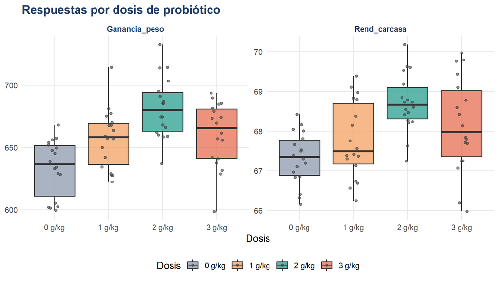

```r
datos %>%
  pivot_longer(all_of(Y), names_to = "Respuesta", values_to = "valor") %>%
  ggplot(aes(Probiotico, valor, fill = Probiotico)) +
  geom_boxplot(alpha = .75, outlier.shape = NA) +
  geom_jitter(width = .12, size = 1.4, alpha = .6, colour = "grey25") +
  facet_wrap(~Respuesta, scales = "free_y") +
  scale_fill_manual(values = pal) +
  labs(title = "Respuestas por dosis de probiótico", x = "Dosis", y = NULL, fill = "Dosis")
```

[figure not shown]

```r
datos %>%
  pivot_longer(all_of(X), names_to = "Covariable", values_to = "x") %>%
  pivot_longer(all_of(Y), names_to = "Respuesta", values_to = "y") %>%
  ggplot(aes(x, y, colour = Probiotico)) +
  geom_point(alpha = .7, size = 1.6) +
  geom_smooth(method = "lm", se = FALSE, linewidth = .9) +
  facet_grid(Respuesta ~ Covariable, scales = "free") +
  scale_colour_manual(values = pal) +
  labs(title = "Relación covariables–respuestas por dosis",
       subtitle = "Rectas aproximadamente paralelas ⇒ evidencia visual de pendientes homogéneas",
       x = NULL, y = NULL, colour = "Dosis")
```

## 3.3 Validación de supuestos

Los supuestos del MANCOVA en DBCA se verifican sobre el modelo ajustado y/o por grupo. Primero se ajusta el modelo (las covariables se colocan **primero** en la fórmula para que el tratamiento se pruebe **ajustado** por ellas).

```r
mod <- manova(cbind(Ganancia_peso, Rend_carcasa) ~ Peso_ini + Edad_ini + Bloque + Probiotico,
              data = datos)
res <- residuals(mod)
n   <- nrow(res)
```

### 3.3.1 Normalidad multivariada

$H_0$: los errores siguen una distribución normal bivariada vs $H_1$: no la siguen. Se aplican el **Shapiro-Wilk multivariado** (Villaseñor-Alva y González-Estrada) y las pruebas de **asimetría y curtosis de Mardia** sobre los residuos del modelo.

```r
# Mardia (asimetría y curtosis multivariadas)
mardia <- function(M) {
  M <- as.matrix(M); n <- nrow(M); p <- ncol(M)
  Mc <- scale(M, scale = FALSE); S <- crossprod(Mc) / n
  D  <- Mc %*% solve(S) %*% t(Mc)
  b1 <- sum(D^3) / n^2;  b2 <- sum(diag(D)^2) / n
  k1 <- n * b1 / 6;      gl <- p * (p + 1) * (p + 2) / 6
  z2 <- (b2 - p * (p + 2)) / sqrt(8 * p * (p + 2) / n)
  data.frame(Prueba = c("Asimetría de Mardia", "Curtosis de Mardia"),
             Estadistico = c(k1, z2), gl = c(gl, NA),
             p = c(pchisq(k1, gl, lower.tail = FALSE), 2 * pnorm(abs(z2), lower.tail = FALSE)))
}

# (a) Shapiro-Wilk multivariado sobre residuos globales
sw_res <- mshapiro.test(t(res))
# (b) Shapiro-Wilk multivariado por dosis (como en clase)
sw_grp <- do.call(rbind, lapply(levels(datos$Probiotico), function(g) {
  r <- mshapiro.test(t(as.matrix(datos[datos$Probiotico == g, Y])))
  data.frame(Grupo = g, W = unname(r$statistic), p = r$p.value)
}))
mar <- mardia(res)

rbind(data.frame(Prueba = "Shapiro-Wilk multivariado (residuos)",
                 Estadistico = unname(sw_res$statistic), gl = NA, p = sw_res$p.value),
      mar) %>% mutate(Decision = ifelse(p < 0.05, "No normal", "Normal"), p = fp(p)) %>%
  tabla("Normalidad multivariada de los residuos")
```

Normalidad multivariada de los residuos

| Prueba | Estadistico | gl | p | Decision |
| --- | --- | --- | --- | --- |
| Shapiro-Wilk multivariado (residuos) | 0.995 | NA | 0.9923 | Normal |
| Asimetría de Mardia | 1.390 | 4 | 0.8460 | Normal |
| Curtosis de Mardia | -0.951 | NA | 0.3415 | Normal |

```r
sw_grp %>% mutate(Decision = ifelse(p < 0.05, "No normal", "Normal"), p = fp(p)) %>%
  tabla("Shapiro-Wilk multivariado por dosis (n = 18 por grupo)")
```

Shapiro-Wilk multivariado por dosis (n = 18 por grupo)

| Grupo | W | p | Decision |
| --- | --- | --- | --- |
| 0 g/kg | 0.934 | 0.2239 | Normal |
| 1 g/kg | 0.943 | 0.3197 | Normal |
| 2 g/kg | 0.950 | 0.4273 | Normal |
| 3 g/kg | 0.934 | 0.2311 | Normal |

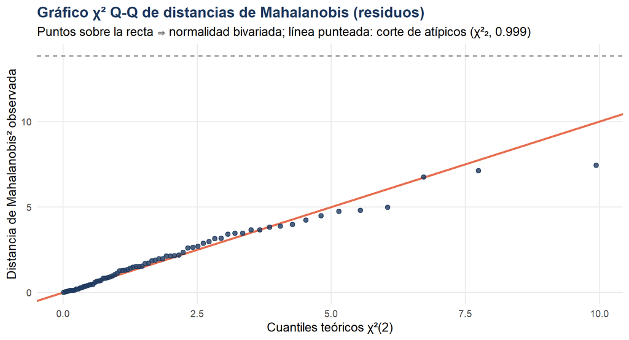

```r
d2 <- mahalanobis(res, colMeans(res), cov(res))
qq <- data.frame(teorico = qchisq((rank(d2) - 0.5) / n, df = 2), observado = d2)
umbral <- qchisq(0.999, 2)

ggplot(qq, aes(teorico, observado)) +
  geom_abline(slope = 1, intercept = 0, colour = naranja, linewidth = 1) +
  geom_point(colour = azul, size = 2, alpha = .8) +
  geom_hline(yintercept = umbral, linetype = "dashed", colour = "grey40") +
  labs(title = "Gráfico χ² Q-Q de distancias de Mahalanobis (residuos)",
       subtitle = "Puntos sobre la recta ⇒ normalidad bivariada; línea punteada: corte de atípicos (χ²₂, 0.999)",
       x = "Cuantiles teóricos χ²(2)", y = "Distancia de Mahalanobis² observada")
```

```r
atipicos <- which(d2 > umbral)
txt_atip <- ifelse(length(atipicos) == 0,
  paste0("no hay observaciones atípicas multivariadas (ninguna distancia de Mahalanobis² supera el corte χ²(2; 0.999) = ", round(umbral, 2), ")"),
  paste0("hay ", length(atipicos), " observación(es) atípica(s) multivariada(s) (supera(n) el corte χ²(2; 0.999) = ", round(umbral, 2), ")"))
```

✅ Interpretación

Con los residuos del modelo, el Shapiro-Wilk multivariado da $W=$ 0.9948 ($p=$ 0.9923) y Mardia da $p=$ 0.8460 (asimetría) y $p=$ 0.3415 (curtosis); en ese caso **no se rechaza** la normalidad multivariada: los residuos son compatibles con una normal bivariada. Además, no hay observaciones atípicas multivariadas (ninguna distancia de Mahalanobis² supera el corte χ²(2; 0.999) = 13.82).

### 3.3.2 Homogeneidad de matrices de covarianza (M de Box)

$H_0:\ \boldsymbol\Sigma_1=\boldsymbol\Sigma_2=\boldsymbol\Sigma_3=\boldsymbol\Sigma_4$ vs $H_1$: al menos una difiere.

```r
bm <- heplots::boxM(cbind(Ganancia_peso, Rend_carcasa) ~ Probiotico, data = datos)
bm
```

```
#>
#>  Box's M-test for Homogeneity of Covariance Matrices
#>
#> data:  datos
#> Chi-Sq (approx.) = 11.68, df = 9, p-value = 0.2
```

✅ Interpretación

M de Box $=$ 11.683 con 9 g.l. y $p=$ 0.2318. Con $\alpha=0.05$ **no** se rechaza $H_0$: las matrices de covarianza de las cuatro dosis son homogéneas.

### 3.3.3 Correlación entre las variables respuesta (esfericidad de Bartlett)

El MANCOVA se justifica si las respuestas están correlacionadas. $H_0:\ \mathbf{R}=\mathbf{I}$ (las respuestas no están correlacionadas) vs $H_1:\ \mathbf{R}\neq\mathbf{I}$. Se aplica sobre los **residuos** (correlación una vez descontados covariables, bloque y tratamiento).

```r
Rres <- cor(res)
bt <- psych::cortest.bartlett(Rres, n = n)
Rres %>% tabla("Matriz de correlación de los residuos")
```

Matriz de correlación de los residuos

|  | Ganancia_peso | Rend_carcasa |
| --- | --- | --- |
| Ganancia_peso | 1.000 | 0.335 |
| Rend_carcasa | 0.335 | 1.000 |

```r
bt
```

```
#> $chisq
#> [1] 8.29
#>
#> $p.value
#> [1] 0.003986
#>
#> $df
#> [1] 1
```

```r
r_raw <- cor.test(datos$Ganancia_peso, datos$Rend_carcasa)
```

✅ Interpretación

$\chi^2=$ 8.29 (1 g.l.), $p=$ 0.0040: se **rechaza** $H_0$. Las respuestas están correlacionadas (r residual = 0.335); sin ajustar, la correlación simple es r = 0.653. Queda así justificado el análisis multivariado frente a dos ANCOVA separados.

### 3.3.4 Supuestos propios del MANCOVA

```r
# (1) Linealidad: términos cuadráticos de las covariables
m_cuad <- manova(cbind(Ganancia_peso, Rend_carcasa) ~ Peso_ini + Edad_ini + Bloque + Probiotico +
                   I(Peso_ini^2) + I(Edad_ini^2), data = datos)
lin1 <- pull_mv(m_cuad, "I(Peso_ini^2)"); lin2 <- pull_mv(m_cuad, "I(Edad_ini^2)")

# (2) Homogeneidad de pendientes: interacción Probiotico × covariable
m_int <- manova(cbind(Ganancia_peso, Rend_carcasa) ~ Peso_ini + Edad_ini + Bloque + Probiotico +
                  Probiotico:Peso_ini + Probiotico:Edad_ini, data = datos)
pen1 <- pull_mv(m_int, "Probiotico:Peso_ini"); pen2 <- pull_mv(m_int, "Probiotico:Edad_ini")

# (3) Aditividad bloque × tratamiento (el DBCA asume que no hay interacción)
m_bxt <- manova(cbind(Ganancia_peso, Rend_carcasa) ~ Peso_ini + Edad_ini + Bloque * Probiotico,
                data = datos)
adi <- pull_mv(m_bxt, "Bloque:Probiotico")

# (4) Las covariables no deben depender del tratamiento
m_cov <- manova(cbind(Peso_ini, Edad_ini) ~ Bloque + Probiotico, data = datos)
ind <- pull_mv(m_cov, "Probiotico")

# (5) Colinealidad entre covariables
r_cov <- cor(datos$Peso_ini, datos$Edad_ini); vif <- 1 / (1 - r_cov^2)

data.frame(
  Supuesto = c("Linealidad: Peso_ini² (cuadrático)", "Linealidad: Edad_ini² (cuadrático)",
               "Pendientes homogéneas: Probiótico × Peso_ini", "Pendientes homogéneas: Probiótico × Edad_ini",
               "Aditividad: Bloque × Probiótico", "Covariables independientes del tratamiento"),
  `Lambda de Wilks` = unname(c(lin1["stat"], lin2["stat"], pen1["stat"], pen2["stat"], adi["stat"], ind["stat"])),
  F = unname(c(lin1["F"], lin2["F"], pen1["F"], pen2["F"], adi["F"], ind["F"])),
  gl1 = unname(c(lin1["df1"], lin2["df1"], pen1["df1"], pen2["df1"], adi["df1"], ind["df1"])),
  gl2 = unname(c(lin1["df2"], lin2["df2"], pen1["df2"], pen2["df2"], adi["df2"], ind["df2"])),
  p = unname(c(lin1["p"], lin2["p"], pen1["p"], pen2["p"], adi["p"], ind["p"])),
  check.names = FALSE) %>%
  mutate(`Conclusión` = ifelse(p >= 0.05, "Se cumple", "No se cumple"), p = fp(p)) %>%
  tabla("Contrastes de los supuestos específicos (H₀: el supuesto se cumple)", digits = 3)
```

Contrastes de los supuestos específicos (H₀: el supuesto se cumple)

| Supuesto | Lambda de Wilks | F | gl1 | gl2 | p | Conclusión |
| --- | --- | --- | --- | --- | --- | --- |
| Linealidad: Peso_ini² (cuadrático) | 0.989 | 0.316 | 2 | 58 | 0.7303 | Se cumple |
| Linealidad: Edad_ini² (cuadrático) | 0.972 | 0.821 | 2 | 58 | 0.4450 | Se cumple |
| Pendientes homogéneas: Probiótico × Peso_ini | 0.944 | 0.528 | 6 | 108 | 0.7857 | Se cumple |
| Pendientes homogéneas: Probiótico × Edad_ini | 0.828 | 1.780 | 6 | 108 | 0.1100 | Se cumple |
| Aditividad: Bloque × Probiótico | 0.581 | 0.937 | 30 | 90 | 0.5661 | Se cumple |
| Covariables independientes del tratamiento | 0.967 | 0.344 | 6 | 124 | 0.9120 | Se cumple |

🧪 Hipótesis de cada contraste

- **Linealidad:** $H_0$: los términos cuadráticos de las covariables no aportan (la relación es lineal).
- **Pendientes homogéneas:** $H_0:\ \mathbf{B}_1=\mathbf{B}_2=\mathbf{B}_3=\mathbf{B}_4$ (no hay interacción tratamiento × covariable). *Es el supuesto crítico del MANCOVA*: si se rechaza, ajustar con una pendiente común no es válido.
- **Aditividad:** $H_0$: no hay interacción bloque × tratamiento (el efecto del probiótico es el mismo en todos los lotes).
- **Independencia covariable–tratamiento:** $H_0$: las covariables no difieren entre dosis (se miden antes del tratamiento y la aleatorización debe balancearlas).

✅ Interpretación

- **Linealidad:** **no** se rechaza $H_0$ (p mínimo = 0.4450), por lo que las relaciones covariable–respuesta son lineales.
- **Pendientes homogéneas:** para Peso_ini $p=$ 0.7857 y para Edad_ini $p=$ 0.1100; no hay interacción, así que **es válido usar una pendiente común** y proceder con el MANCOVA.
- **Aditividad del DBCA:** $p=$ 0.5661; el modelo aditivo (sin interacción bloque × dosis) es adecuado.
- **Covariables independientes del tratamiento:** $p=$ 0.9120; la aleatorización balanceó las covariables entre dosis, de modo que el ajuste no elimina parte del efecto del tratamiento.
- **Colinealidad entre covariables:** r(Peso_ini, Edad_ini) = 0.099, VIF = 1.01 (sin problemas de colinealidad, VIF < 5).

### 3.3.5 Resumen de la validación

```r
cumple <- function(ok) ifelse(ok,
  cell_spec("✔ Cumple", color = "white", background = verde, bold = TRUE, extra_css = "padding:2px 8px;border-radius:10px;"),
  cell_spec("✘ No cumple", color = "white", background = naranja, bold = TRUE, extra_css = "padding:2px 8px;border-radius:10px;"))

resumen <- data.frame(
  Supuesto = c("Normalidad multivariada (Shapiro-Wilk MV, residuos)", "Normalidad: asimetría de Mardia",
               "Normalidad: curtosis de Mardia", "Homogeneidad de covarianzas (M de Box)",
               "Correlación entre respuestas (Bartlett)", "Linealidad covariable–respuesta",
               "Pendientes homogéneas", "Aditividad bloque × dosis", "Covariables independientes del tratamiento"),
  Prueba = c("mshapiro.test", "Mardia", "Mardia", "boxM", "cortest.bartlett",
             "Términos cuadráticos", "Interacción dosis × covariable", "Interacción bloque × dosis", "MANOVA de covariables"),
  p = unname(c(sw_res$p.value, mar$p, bm$p.value, bt$p.value, min(lin1["p"], lin2["p"]),
        min(pen1["p"], pen2["p"]), adi["p"], ind["p"])),
  ok = unname(c(sw_res$p.value >= .05, mar$p >= .05, bm$p.value >= .05, bt$p.value < .05,
         min(lin1["p"], lin2["p"]) >= .05, min(pen1["p"], pen2["p"]) >= .05, adi["p"] >= .05, ind["p"] >= .05))
)
resumen %>% mutate(p = fp(p), Resultado = cumple(ok)) %>% select(-ok) %>%
  kable(format = "html", escape = FALSE, align = "llcc", caption = "Resumen de la validación de supuestos (α = 0.05)") %>%
  kable_styling(bootstrap_options = c("striped", "hover"), full_width = FALSE) %>%
  row_spec(0, bold = TRUE, color = "white", background = azul)
```

Resumen de la validación de supuestos (α = 0.05)

| Supuesto | Prueba | p | Resultado |
| --- | --- | --- | --- |
| Normalidad multivariada (Shapiro-Wilk MV, residuos) | mshapiro.test | 0.9923 | ✔ Cumple |
| Normalidad: asimetría de Mardia | Mardia | 0.8460 | ✔ Cumple |
| Normalidad: curtosis de Mardia | Mardia | 0.3415 | ✔ Cumple |
| Homogeneidad de covarianzas (M de Box) | boxM | 0.2318 | ✔ Cumple |
| Correlación entre respuestas (Bartlett) | cortest.bartlett | 0.0040 | ✔ Cumple |
| Linealidad covariable–respuesta | Términos cuadráticos | 0.4450 | ✔ Cumple |
| Pendientes homogéneas | Interacción dosis × covariable | 0.1100 | ✔ Cumple |
| Aditividad bloque × dosis | Interacción bloque × dosis | 0.5661 | ✔ Cumple |
| Covariables independientes del tratamiento | MANOVA de covariables | 0.9120 | ✔ Cumple |

## 3.4 Ejecución del MANCOVA y resultados

### 3.4.1 Matrices de sumas de cuadrados y productos cruzados

```r
SS  <- summary(mod)$SS
Tot <- Reduce("+", SS)
Wm  <- SS$Residuals            # matriz de error E
Hd  <- SS$Probiotico           # matriz de hipótesis del tratamiento

mat <- function(M, titulo) {
  cat("\n\n**", titulo, "**\n\n", sep = "")
  print(kable(M, digits = 3, align = "c") %>%
          kable_styling(full_width = FALSE, bootstrap_options = c("striped", "condensed")))
}
mat(SS$Probiotico, "H — Dosis de probiótico (SCPC ajustada por covariables y bloque)")
```

**H — Dosis de probiótico (SCPC ajustada por covariables y bloque)**

|  | Ganancia_peso | Rend_carcasa |
| --- | --- | --- |
| Ganancia_peso | 17180.4 | 511.31 |
| Rend_carcasa | 511.3 | 15.97 |

```r
mat(SS$Bloque,     "Bloque")
```

**Bloque**

|  | Ganancia_peso | Rend_carcasa |
| --- | --- | --- |
| Ganancia_peso | 8606.6 | 140.339 |
| Rend_carcasa | 140.3 | 3.806 |

```r
mat(SS$Peso_ini,   "Covariable 1: Peso_ini")
```

**Covariable 1: Peso_ini**

|  | Ganancia_peso | Rend_carcasa |
| --- | --- | --- |
| Ganancia_peso | 7659 | 253.05 |
| Rend_carcasa | 253 | 8.36 |

```r
mat(SS$Edad_ini,   "Covariable 2: Edad_ini")
```

**Covariable 2: Edad_ini**

|  | Ganancia_peso | Rend_carcasa |
| --- | --- | --- |
| Ganancia_peso | 8900.2 | 186.622 |
| Rend_carcasa | 186.6 | 3.913 |

```r
mat(Wm,            "E — Residual (error)")
```

**E — Residual (error)**

|  | Ganancia_peso | Rend_carcasa |
| --- | --- | --- |
| Ganancia_peso | 18082.1 | 293.64 |
| Rend_carcasa | 293.6 | 42.41 |

```r
mat(Tot,           "T — Total corregido")
```

**T — Total corregido**

|  | Ganancia_peso | Rend_carcasa |
| --- | --- | --- |
| Ganancia_peso | 60428 | 1384.96 |
| Rend_carcasa | 1385 | 74.46 |

### 3.4.2 Pruebas multivariadas

```r
tab_mv <- bind_rows(lapply(c("Pillai", "Wilks", "Hotelling-Lawley", "Roy"), function(ts) {
  st <- summary(mod, test = ts)$stats
  st <- st[rownames(st) != "Residuals", , drop = FALSE]
  data.frame(Termino = rownames(st), Prueba = ts, gl = st[, "Df"], Valor = st[, ts],
             F = st[, "approx F"], gl_num = st[, "num Df"], gl_den = st[, "den Df"],
             p = st[, "Pr(>F)"], row.names = NULL)
}))
g <- function(term, test, col) tab_mv[tab_mv$Termino == term & tab_mv$Prueba == test, col]

tab_mv %>%
  mutate(Sig = sig(p), p = fp(p)) %>%
  tabla("Pruebas multivariadas por término (SC secuencial: covariables → bloque → dosis)", digits = 4) %>%
  row_spec(which(tab_mv$Termino == "Probiotico"), bold = TRUE, background = "#FFF1E6") %>%
  row_spec(which(tab_mv$Termino %in% c("Peso_ini", "Edad_ini")), background = "#E6F5F2") %>%
  footnote(general = "Naranja: efecto del probiótico (contraste principal). Verde: covariables. *** p<0.001, ** p<0.01, * p<0.05, ns no significativo. Los p de covariables y bloque de esta tabla son secuenciales (no ajustados por los términos posteriores); para interpretarlos use la prueba tipo II de abajo.")
```

Pruebas multivariadas por término (SC secuencial: covariables → bloque → dosis)

| Termino | Prueba | gl | Valor | F | gl_num | gl_den | p | Sig |
| --- | --- | --- | --- | --- | --- | --- | --- | --- |
| Peso_ini | Pillai | 1 | 0.3248 | 14.430 | 2 | 60 | < 0.001 | *** |
| Edad_ini | Pillai | 1 | 0.3322 | 14.925 | 2 | 60 | < 0.001 | *** |
| Bloque | Pillai | 5 | 0.3612 | 2.689 | 10 | 122 | 0.0052 | ** |
| Probiotico | Pillai | 3 | 0.5268 | 7.271 | 6 | 122 | < 0.001 | *** |
| Peso_ini | Wilks | 1 | 0.6752 | 14.430 | 2 | 60 | < 0.001 | *** |
| Edad_ini | Wilks | 1 | 0.6678 | 14.925 | 2 | 60 | < 0.001 | *** |
| Bloque | Wilks | 5 | 0.6513 | 2.870 | 10 | 120 | 0.0030 | ** |
| Probiotico | Wilks | 3 | 0.4824 | 8.794 | 6 | 120 | < 0.001 | *** |
| Peso_ini | Hotelling-Lawley | 1 | 0.4810 | 14.430 | 2 | 60 | < 0.001 | *** |
| Edad_ini | Hotelling-Lawley | 1 | 0.4975 | 14.925 | 2 | 60 | < 0.001 | *** |
| Bloque | Hotelling-Lawley | 5 | 0.5163 | 3.046 | 10 | 118 | 0.0018 | ** |
| Probiotico | Hotelling-Lawley | 3 | 1.0537 | 10.361 | 6 | 118 | < 0.001 | *** |
| Peso_ini | Roy | 1 | 0.4810 | 14.430 | 2 | 60 | < 0.001 | *** |
| Edad_ini | Roy | 1 | 0.4975 | 14.925 | 2 | 60 | < 0.001 | *** |
| Bloque | Roy | 5 | 0.4760 | 5.807 | 5 | 61 | < 0.001 | *** |
| Probiotico | Roy | 3 | 1.0353 | 21.050 | 3 | 61 | < 0.001 | *** |

Note:  
Naranja: efecto del probiótico (contraste principal). Verde: covariables. *** p<0.001, ** p<0.01, * p<0.05, ns no significativo. Los p de covariables y bloque de esta tabla son secuenciales (no ajustados por los términos posteriores); para interpretarlos use la prueba tipo II de abajo.

Como control, la prueba de **tipo II** (independiente del orden de los términos: cada efecto se ajusta por todos los demás) de `car::Manova`. Para **covariables y bloque** son estos p-valores los que se interpretan; para la dosis ambos coinciden porque es el último término:

```r
car::Manova(mod, type = "II", test.statistic = "Wilks")
```

```
#>
#> Type II MANOVA Tests: Wilks test statistic
#>            Df test stat approx F num Df den Df      Pr(>F)
#> Peso_ini    1     0.901     3.28      2     60     0.04453 *
#> Edad_ini    1     0.778     8.54      2     60     0.00055 ***
#> Bloque      5     0.634     3.08     10    120     0.00163 **
#> Probiotico  3     0.482     8.79      6    120 0.000000061 ***
#> ---
#> Signif. codes:  0 '***' 0.001 '**' 0.01 '*' 0.05 '.' 0.1 ' ' 1
```

```r
p_prob <- g("Probiotico", "Wilks", "p")
sig_prob <- p_prob < 0.05
L  <- g("Probiotico", "Wilks", "Valor")
s_w <- min(2, 3)  # s = min(p, gl_hipotesis) = min(2, 3)
eta_w   <- 1 - L^(1 / s_w)                      # eta² parcial multivariado (Wilks)
eta_cls <- 1 - det(SS$Bloque + SS$Peso_ini + SS$Edad_ini + Wm) / det(Tot)   # criterio usado en clase

# Pruebas ajustadas (tipo II) de covariables y bloque: cada término se ajusta por TODOS los demás.
# En la tabla secuencial, Peso_ini y Edad_ini se prueban antes del bloque, así que su p-valor sale sobrestimado.
mod_lm <- lm(cbind(Ganancia_peso, Rend_carcasa) ~ Peso_ini + Edad_ini + Bloque + Probiotico, data = datos)
pull_II <- function(term) {
  rhs <- setdiff(attr(terms(mod_lm), "term.labels"), term)
  m0  <- lm(as.formula(paste("cbind(Ganancia_peso, Rend_carcasa) ~", paste(rhs, collapse = " + "))), data = datos)
  a   <- anova(m0, mod_lm, test = "Wilks")
  c(stat = a[2, "Wilks"], F = a[2, "approx F"], df1 = a[2, "num Df"], df2 = a[2, "den Df"], p = a[2, "Pr(>F)"])
}
II_peso <- pull_II("Peso_ini"); II_edad <- pull_II("Edad_ini"); II_blq <- pull_II("Bloque")

# Paso previo del MANCOVA: ¿dependen las respuestas de las covariables (H0: B = 0, conjuntamente)?
m_nocov <- lm(cbind(Ganancia_peso, Rend_carcasa) ~ Bloque + Probiotico, data = datos)
a_cov <- anova(m_nocov, mod_lm, test = "Wilks")
p_cov <- a_cov[2, "Pr(>F)"]
```

✅ Interpretación del contraste principal (dosis de probiótico)

- **Pillai:** $V=$ 0.5268, $F(6,122)=$ 7.271, $p=$ < 0.001.
- **Wilks:** $\Lambda=$ 0.4824, $F(6,120)=$ 8.794, $p=$ < 0.001.
- **Hotelling-Lawley:** $T=$ 1.0537, $p=$ < 0.001.
- **Roy:** $\theta=$ 1.0353, $p=$ < 0.001.

Con $\alpha=0.05$ las cuatro pruebas coinciden: se **rechaza** $H_0$. **Existe efecto del probiótico sobre el vector de respuestas** (ganancia de peso y rendimiento de carcasa), una vez ajustado por peso inicial, edad inicial y bloque: al menos una dosis tiene un vector de medias ajustadas distinto.

**Paso previo: ¿dependen las respuestas de las covariables?** Contraste conjunto $H_0:\ \mathbf{B}=\mathbf{0}$: $\Lambda=$ 0.7262, $F(4,120)=$ 5.203, $p=$ < 0.001. Se rechaza $H_0$: las respuestas dependen de las covariables, por lo que corresponde el MANCOVA (y no un MANOVA en DBCA).

**Efectos secundarios (pruebas tipo II, ajustadas por los demás términos).** Peso_ini ($p=$ 0.0445) y Edad_ini ($p=$ < 0.001): ambas covariables son significativas, por lo que **el ajuste por covariables es pertinente**. Bloque: $p=$ 0.0016 (el agrupamiento en lotes fue efectivo para controlar variabilidad).

### 3.4.3 Tamaño del efecto y eficiencia del diseño

```r
# Modelos de comparación
m_sincov <- manova(cbind(Ganancia_peso, Rend_carcasa) ~ Bloque + Probiotico, data = datos)           # MANOVA en DBCA
m_dca    <- manova(cbind(Ganancia_peso, Rend_carcasa) ~ Peso_ini + Edad_ini + Probiotico, data = datos) # MANCOVA en DCA

Ecm <- function(m) { E <- summary(m)$SS$Residuals; E / m$df.residual }   # matriz de cuadrados medios del error
comp <- data.frame(
  Modelo = c("MANCOVA en DBCA (propuesto)", "MANOVA en DBCA (sin covariables)", "MANCOVA en DCA (sin bloque)"),
  gl_error = c(mod$df.residual, m_sincov$df.residual, m_dca$df.residual),
  `Lambda de Wilks (dosis)` = unname(c(L, pull_mv(m_sincov, "Probiotico")["stat"], pull_mv(m_dca, "Probiotico")["stat"])),
  `F aproximado` = unname(c(g("Probiotico","Wilks","F"), pull_mv(m_sincov, "Probiotico")["F"], pull_mv(m_dca, "Probiotico")["F"])),
  `Varianza generalizada del error |E/gl|` = c(det(Ecm(mod)), det(Ecm(m_sincov)), det(Ecm(m_dca))),
  check.names = FALSE)
comp$`Razón |E/gl| vs. modelo propuesto` <- comp$`Varianza generalizada del error |E/gl|` / comp$`Varianza generalizada del error |E/gl|`[1]
comp %>% tabla("Comparación de modelos: aporte de las covariables y del bloqueo", digits = 4) %>%
  row_spec(1, bold = TRUE, background = "#E6F5F2")
```

Comparación de modelos: aporte de las covariables y del bloqueo

| Modelo | gl_error | Lambda de Wilks (dosis) | F aproximado | Varianza generalizada del error &#124;E/gl&#124; | Razón &#124;E/gl&#124; vs. modelo propuesto |
| --- | --- | --- | --- | --- | --- |
| MANCOVA en DBCA (propuesto) | 61 | 0.4824 | 8.794 | 182.9 | 1.000 |
| MANOVA en DBCA (sin covariables) | 63 | 0.5052 | 8.411 | 236.1 | 1.291 |
| MANCOVA en DCA (sin bloque) | 66 | 0.5855 | 6.649 | 246.6 | 1.348 |

```r
ef_cov <- det(Ecm(m_sincov)) / det(Ecm(mod))
ef_blq <- det(Ecm(m_dca)) / det(Ecm(mod))
r2 <- sapply(Y, function(y) summary(lm(as.formula(paste(y, "~ Peso_ini + Edad_ini + Bloque + Probiotico")), data = datos))$r.squared)
```

✅ Interpretación

- **Tamaño del efecto de la dosis:** $\eta^2_{parcial}=1-\Lambda^{1/s}=$ 0.305 (con $s=\min(p,\,gl_H)=2$): la dosis explica cerca del 30.5% de la variabilidad multivariada no atribuible a covariables y bloque. Con el criterio usado en clase, $\eta^2=1-|\mathbf{B}+\mathbf{X}_1+\mathbf{X}_2+\mathbf{E}|/|\mathbf{T}|=$ 0.316.
- **R² univariado del modelo completo:** Ganancia de peso = 0.701; Rendimiento de carcasa = 0.43.
- **Eficiencia:** la varianza generalizada del error del modelo con covariables es 1.29 veces menor que la del MANOVA sin covariables, y 1.35 veces menor que la del MANCOVA en DCA (sin bloque). Ambos controles (covariables y bloques) **aumentan la precisión** del experimento.

### 3.4.4 Análisis univariado de seguimiento (ANCOVA por respuesta)

Como el contraste multivariado fue significativo (condición cumplida), se explora **en cuál(es) respuesta(s)** se manifiesta el efecto. Para controlar el error tipo I global al hacer 2 pruebas se usa la corrección de **Bonferroni**: $\alpha^*=0.05/2=0.025$.

```r
uni <- lapply(setNames(Y, Y), function(y) {
  fit <- lm(as.formula(paste(y, "~ Peso_ini + Edad_ini + Bloque + Probiotico")), data = datos)
  list(fit = fit, aov = car::Anova(fit, type = "II"))
})

tab_uni <- bind_rows(lapply(Y, function(y) {
  a <- uni[[y]]$aov
  a <- a[rownames(a) != "Residuals", ]
  data.frame(Respuesta = y, Fuente = rownames(a), SC = a[["Sum Sq"]], gl = a[["Df"]],
             CM = a[["Sum Sq"]] / a[["Df"]], F = a[["F value"]], p = a[["Pr(>F)"]], row.names = NULL)
}))

tab_uni %>% mutate(Sig = sig(p), `Sig. Bonferroni` = ifelse(p < 0.025, "Sí", "No"), p = fp(p)) %>%
  tabla("ANCOVA univariado en DBCA (SC tipo II)", digits = 3) %>%
  row_spec(which(tab_uni$Fuente == "Probiotico"), bold = TRUE, background = "#FFF1E6") %>%
  collapse_rows(columns = 1, valign = "top")
```

ANCOVA univariado en DBCA (SC tipo II)

Respuesta

Fuente

SC

gl

CM

F

p

Sig

Sig. Bonferroni

Ganancia_peso

Peso_ini

1152.304

1

1152.304

3.887

0.0532

ns

No

Edad_ini

5106.796

1

5106.796

17.228

< 0.001

***

Sí

Bloque

9401.955

5

1880.391

6.344

< 0.001

***

Sí

Probiotico

17180.449

3

5726.816

19.319

< 0.001

***

Sí

Rend_carcasa

Peso_ini

3.463

1

3.463

4.981

0.0293

No

Edad_ini

2.081

1

2.081

2.994

0.0886

ns

No

Bloque

4.096

5

0.819

1.178

0.3302

ns

No

Probiotico

15.974

3

5.325

7.659

< 0.001

***

Sí

```r
coef_cov <- bind_rows(lapply(Y, function(y) {
  cf <- summary(uni[[y]]$fit)$coefficients[c("Peso_ini", "Edad_ini"), ]
  data.frame(Respuesta = y, Covariable = rownames(cf), Coeficiente = cf[, 1], EE = cf[, 2],
             t = cf[, 3], p = fp(cf[, 4]), row.names = NULL)
}))
coef_cov %>% tabla("Coeficientes de regresión de las covariables (pendiente común)", digits = 4) %>%
  collapse_rows(columns = 1, valign = "top")
```

Coeficientes de regresión de las covariables (pendiente común)

| Respuesta | Covariable | Coeficiente | EE | t | p |
| --- | --- | --- | --- | --- | --- |
| Ganancia_peso | Peso_ini | 0.1630 | 0.0827 | 1.972 | 0.0532 |
|  | Edad_ini | -3.8468 | 0.9268 | -4.151 | < 0.001 |
| Rend_carcasa | Peso_ini | 0.0089 | 0.0040 | 2.232 | 0.0293 |
|  | Edad_ini | -0.0777 | 0.0449 | -1.730 | 0.0886 |

```r
p_gp <- tab_uni$p[tab_uni$Respuesta == "Ganancia_peso" & tab_uni$Fuente == "Probiotico"]
p_rc <- tab_uni$p[tab_uni$Respuesta == "Rend_carcasa" & tab_uni$Fuente == "Probiotico"]
```

✅ Interpretación

- **Ganancia de peso:** el efecto de la dosis es significativo ($p=$ < 0.001; umbral Bonferroni 0.025).
- **Rendimiento de carcasa:** el efecto de la dosis es significativo ($p=$ < 0.001).
- **Covariables:** por cada gramo adicional de peso inicial, la ganancia de peso cambia en 0.163 g; por cada día adicional de edad inicial cambia en -3.85 g (manteniendo lo demás constante). Para el rendimiento de carcasa los cambios son de 0.0089 y -0.078 puntos porcentuales, respectivamente. El signo negativo de la edad refleja que **animales más viejos al inicio crecen menos** en el periodo.

### 3.4.5 Medias ajustadas

Las **medias ajustadas** (marginales estimadas) son las medias de cada dosis evaluadas en el *valor promedio de las covariables*; permiten comparar dosis “como si” todos los cuyes hubieran partido con el mismo peso y edad.

```r
emm_u <- lapply(uni, function(u) emmeans(u$fit, ~ Probiotico))

ajustadas <- bind_rows(lapply(Y, function(y) cbind(Respuesta = y, as.data.frame(emm_u[[y]]))))
crudas <- datos %>% group_by(Probiotico) %>% summarise(across(all_of(Y), mean)) %>%
  pivot_longer(all_of(Y), names_to = "Respuesta", values_to = "media_cruda")
ajustadas <- left_join(ajustadas, crudas, by = c("Respuesta", "Probiotico"))

ajustadas %>% select(Respuesta, Probiotico, `Media cruda` = media_cruda, `Media ajustada` = emmean,
                     EE = SE, `IC inf` = lower.CL, `IC sup` = upper.CL) %>%
  tabla("Medias crudas vs medias ajustadas por covariables (IC 95%)", digits = 3) %>%
  collapse_rows(columns = 1, valign = "top")
```

Medias crudas vs medias ajustadas por covariables (IC 95%)

| Respuesta | Probiotico | Media cruda | Media ajustada | EE | IC inf | IC sup |
| --- | --- | --- | --- | --- | --- | --- |
| Ganancia_peso | 0 g/kg | 633.49 | 636.15 | 4.102 | 627.95 | 644.35 |
|  | 1 g/kg | 656.82 | 656.54 | 4.062 | 648.42 | 664.67 |
|  | 2 g/kg | 681.51 | 680.28 | 4.068 | 672.14 | 688.41 |
|  | 3 g/kg | 660.27 | 659.12 | 4.068 | 650.99 | 667.25 |
| Rend_carcasa | 0 g/kg | 67.32 | 67.38 | 0.199 | 66.99 | 67.78 |
|  | 1 g/kg | 67.77 | 67.77 | 0.197 | 67.38 | 68.16 |
|  | 2 g/kg | 68.71 | 68.68 | 0.197 | 68.29 | 69.07 |
|  | 3 g/kg | 68.15 | 68.12 | 0.197 | 67.72 | 68.51 |

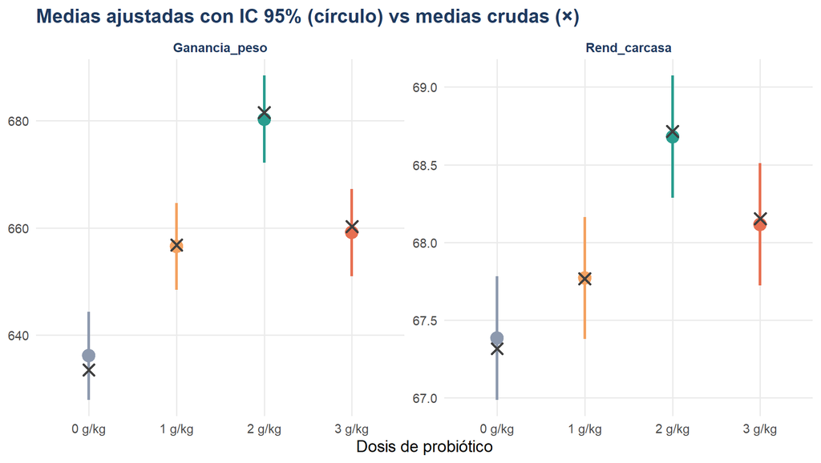

```r
ggplot(ajustadas, aes(Probiotico, emmean, colour = Probiotico)) +
  geom_pointrange(aes(ymin = lower.CL, ymax = upper.CL), linewidth = 1, size = .9) +
  geom_point(aes(y = media_cruda), shape = 4, size = 3, stroke = 1.2, colour = "grey25") +
  facet_wrap(~Respuesta, scales = "free_y") +
  scale_colour_manual(values = pal, guide = "none") +
  labs(title = "Medias ajustadas con IC 95% (círculo) vs medias crudas (×)",
       x = "Dosis de probiótico", y = NULL)
```

### 3.4.6 Comparaciones múltiples multivariadas entre dosis

Para ubicar **qué dosis difieren** se comparan los vectores de medias ajustadas por pares con $T^2$ de Hotelling (`emmeans::mvcontrast`), ajustando el valor $p$ por **Bonferroni** y por **Holm**.

$H_0:\ \boldsymbol\mu^{aj}_i=\boldsymbol\mu^{aj}_{i'}$ vs $H_1:\ \boldsymbol\mu^{aj}_i\neq\boldsymbol\mu^{aj}_{i'}$

```r
fit_lm <- lm(cbind(Ganancia_peso, Rend_carcasa) ~ Peso_ini + Edad_ini + Bloque + Probiotico, data = datos)
emm_mv <- emmeans(fit_lm, ~ Probiotico | rep.meas)

mv_bonf <- as.data.frame(mvcontrast(emm_mv, method = "pairwise", mult.name = "rep.meas", adjust = "bonferroni"))
mv_holm <- as.data.frame(mvcontrast(emm_mv, method = "pairwise", mult.name = "rep.meas", adjust = "holm"))

mv_bonf$p.holm <- mv_holm$p.value
mv_bonf %>%
  transmute(Contraste = contrast, `T²` = T.square, gl1 = df1, gl2 = df2, F = F.ratio,
            `p (Bonferroni)` = fp(p.value), `p (Holm)` = fp(p.holm),
            Decisión = ifelse(p.value < 0.05, "Difieren", "No difieren")) %>%
  tabla("Comparaciones por pares de vectores de medias ajustadas", digits = 3)
```

Comparaciones por pares de vectores de medias ajustadas

|  | Contraste | T² | gl1 | gl2 | F | p (Bonferroni) | p (Holm) | Decisión |
| --- | --- | --- | --- | --- | --- | --- | --- | --- |
| 1 | (0 g/kg) - (1 g/kg) | 12.500 | 2 | 60 | 6.147 | 0.0224 | 0.0075 | Difieren |
| 3 | (0 g/kg) - (2 g/kg) | 62.546 | 2 | 60 | 30.760 | < 0.001 | < 0.001 | Difieren |
| 5 | (0 g/kg) - (3 g/kg) | 17.502 | 2 | 60 | 8.608 | 0.0031 | 0.0021 | Difieren |
| 7 | (1 g/kg) - (2 g/kg) | 21.043 | 2 | 60 | 10.349 | < 0.001 | < 0.001 | Difieren |
| 9 | (1 g/kg) - (3 g/kg) | 1.537 | 2 | 60 | 0.756 | 1.0000 | 0.4740 | No difieren |
| 11 | (2 g/kg) - (3 g/kg) | 14.295 | 2 | 60 | 7.030 | 0.0108 | 0.0054 | Difieren |

```r
# Cada dosis frente al control (0 g/kg)
mv_ctrl <- as.data.frame(mvcontrast(emm_mv, method = "trt.vs.ctrl1", mult.name = "rep.meas", adjust = "bonferroni"))
mv_ctrl %>%
  transmute(Contraste = contrast, `T²` = T.square, gl1 = df1, gl2 = df2, F = F.ratio,
            `p (Bonferroni)` = fp(p.value), Decisión = ifelse(p.value < 0.05, "Difiere del control", "Igual al control")) %>%
  tabla("Cada dosis vs. control (0 g/kg)", digits = 3)
```

Cada dosis vs. control (0 g/kg)

|  | Contraste | T² | gl1 | gl2 | F | p (Bonferroni) | Decisión |
| --- | --- | --- | --- | --- | --- | --- | --- |
| 1 | (1 g/kg) - (0 g/kg) | 12.50 | 2 | 60 | 6.147 | 0.0112 | Difiere del control |
| 3 | (2 g/kg) - (0 g/kg) | 62.55 | 2 | 60 | 30.760 | < 0.001 | Difiere del control |
| 5 | (3 g/kg) - (0 g/kg) | 17.50 | 2 | 60 | 8.608 | 0.0016 | Difiere del control |

Pruebas **univariadas** por pares (Tukey) para precisar en qué variable difieren:

```r
tuk <- bind_rows(lapply(Y, function(y) cbind(Respuesta = y, as.data.frame(pairs(emm_u[[y]], adjust = "tukey")))))
tuk %>% transmute(Respuesta, Contraste = contrast, Diferencia = estimate, EE = SE, t = t.ratio,
                  `p (Tukey)` = fp(p.value), Decisión = ifelse(p.value < 0.05, "Difieren", "No difieren")) %>%
  tabla("Comparaciones univariadas por pares (medias ajustadas, Tukey)", digits = 3) %>%
  collapse_rows(columns = 1, valign = "top")
```

Comparaciones univariadas por pares (medias ajustadas, Tukey)

| Respuesta | Contraste | Diferencia | EE | t | p (Tukey) | Decisión |
| --- | --- | --- | --- | --- | --- | --- |
| Ganancia_peso | (0 g/kg) - (1 g/kg) | -20.396 | 5.779 | -3.529 | 0.0043 | Difieren |
|  | (0 g/kg) - (2 g/kg) | -44.127 | 5.806 | -7.600 | < 0.001 | Difieren |
|  | (0 g/kg) - (3 g/kg) | -22.973 | 5.804 | -3.958 | 0.0011 | Difieren |
|  | (1 g/kg) - (2 g/kg) | -23.731 | 5.747 | -4.129 | < 0.001 | Difieren |
|  | (1 g/kg) - (3 g/kg) | -2.576 | 5.749 | -0.448 | 0.9698 | No difieren |
|  | (2 g/kg) - (3 g/kg) | 21.155 | 5.740 | 3.686 | 0.0027 | Difieren |
| Rend_carcasa | (0 g/kg) - (1 g/kg) | -0.387 | 0.280 | -1.382 | 0.5150 | No difieren |
|  | (0 g/kg) - (2 g/kg) | -1.296 | 0.281 | -4.610 | < 0.001 | Difieren |
|  | (0 g/kg) - (3 g/kg) | -0.732 | 0.281 | -2.604 | 0.0547 | No difieren |
|  | (1 g/kg) - (2 g/kg) | -0.909 | 0.278 | -3.267 | 0.0094 | Difieren |
|  | (1 g/kg) - (3 g/kg) | -0.345 | 0.278 | -1.239 | 0.6046 | No difieren |
|  | (2 g/kg) - (3 g/kg) | 0.564 | 0.278 | 2.030 | 0.1885 | No difieren |

```r
pares_mv  <- paste(mv_bonf$contrast[mv_bonf$p.value < 0.05], collapse = "; ")
mejor_gp  <- as.character(ajustadas$Probiotico[ajustadas$Respuesta == "Ganancia_peso"][which.max(ajustadas$emmean[ajustadas$Respuesta == "Ganancia_peso"])])
mejor_rc  <- as.character(ajustadas$Probiotico[ajustadas$Respuesta == "Rend_carcasa"][which.max(ajustadas$emmean[ajustadas$Respuesta == "Rend_carcasa"])])
```

✅ Interpretación

Con Bonferroni, los pares de dosis cuyos vectores de medias ajustadas difieren son: **(0 g/kg) - (1 g/kg); (0 g/kg) - (2 g/kg); (0 g/kg) - (3 g/kg); (1 g/kg) - (2 g/kg); (2 g/kg) - (3 g/kg)**. La mayor media ajustada de ganancia de peso corresponde a la dosis **2 g/kg** y la de rendimiento de carcasa a **2 g/kg**. Ambas variables coinciden en la mejor dosis, lo que facilita la recomendación. Que la dosis más alta (3 g/kg) no supere a la intermedia sugiere una **respuesta curvilínea** (efecto de saturación).

### 3.4.7 Representación gráfica multivariada

#### 3.4.7.1 Elipse de hipótesis–error (HE-plot)

La elipse **H** (naranja) resume la variación entre dosis y la elipse **E** (azul) la variación residual. El efecto es significativo cuando la elipse H *sobresale* de la E escalada; los centros de los tratamientos aparecen como puntos y su separación indica la dirección del efecto.

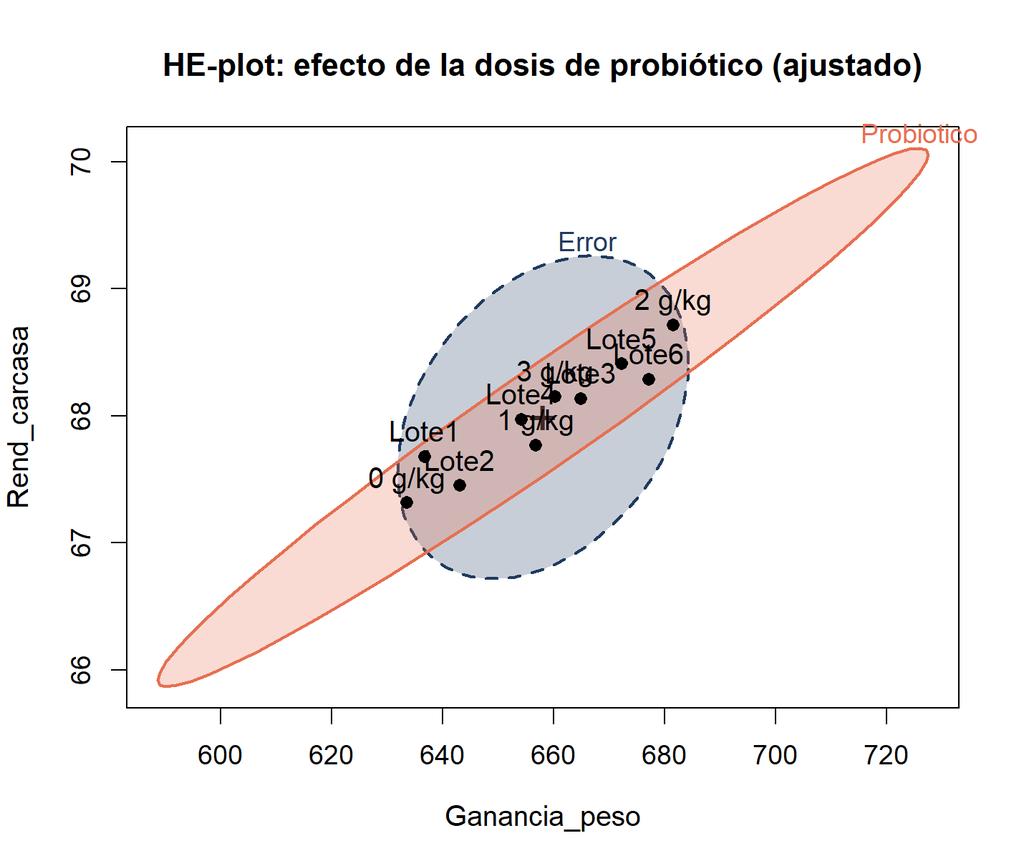

```r
heplot(mod, terms = "Probiotico", variables = c(1, 2), fill = TRUE, fill.alpha = 0.25,
       col = c(azul, naranja), lwd = 2, cex = 1.1, cex.lab = 1.1,
       main = "HE-plot: efecto de la dosis de probiótico (ajustado)")
```

#### 3.4.7.2 Vectores de medias ajustadas en el plano de respuestas

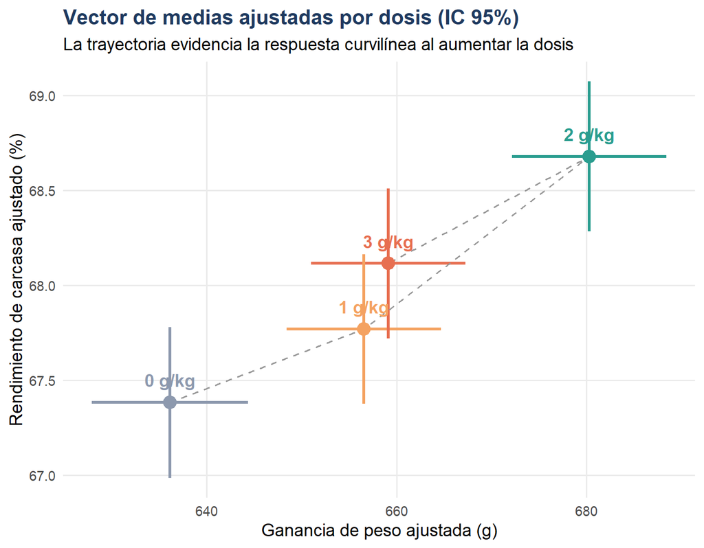

```r
em2 <- as.data.frame(emm_mv) %>%
  select(Probiotico, rep.meas, emmean, lower.CL, upper.CL) %>%
  pivot_wider(names_from = rep.meas, values_from = c(emmean, lower.CL, upper.CL))

ggplot(em2, aes(emmean_Ganancia_peso, emmean_Rend_carcasa, colour = Probiotico)) +
  geom_segment(aes(x = lower.CL_Ganancia_peso, xend = upper.CL_Ganancia_peso,
                   y = emmean_Rend_carcasa, yend = emmean_Rend_carcasa), linewidth = 1) +
  geom_segment(aes(x = emmean_Ganancia_peso, xend = emmean_Ganancia_peso,
                   y = lower.CL_Rend_carcasa, yend = upper.CL_Rend_carcasa), linewidth = 1) +
  geom_path(aes(group = 1), colour = "grey60", linetype = "dashed") +
  geom_point(size = 4) +
  geom_text(aes(label = Probiotico), vjust = -1.2, fontface = "bold", show.legend = FALSE) +
  scale_colour_manual(values = pal, guide = "none") +
  labs(title = "Vector de medias ajustadas por dosis (IC 95%)",
       subtitle = "La trayectoria evidencia la respuesta curvilínea al aumentar la dosis",
       x = "Ganancia de peso ajustada (g)", y = "Rendimiento de carcasa ajustado (%)")
```

✅ Interpretación gráfica

El HE-plot confirma visualmente la prueba multivariada: la elipse H se proyecta claramente fuera de la elipse de error, es decir, la variación entre dosis es mayor que la esperada por azar. Los centros de las dosis se ordenan a lo largo de una **diagonal positiva**: las dosis que más aumentan la ganancia de peso también incrementan el rendimiento de carcasa, coherente con la correlación positiva entre las respuestas.

## 3.5 Discusión

💬 Contraste con el problema práctico

1. **Por qué el enfoque multivariado.** Las respuestas están correlacionadas (r residual = 0.34), de modo que la decisión sobre la dosis debe tomarse sobre el vector $(\text{ganancia}, \text{rendimiento})$ y no sobre cada variable aislada. El MANCOVA protege el error tipo I global y aprovecha la covarianza entre respuestas.
2. **Papel de las covariables.** Peso inicial y edad inicial resultaron significativas (Wilks tipo II $p=$ 0.0445 y < 0.001). Al ajustar por ellas, la varianza generalizada del error se redujo 1.29 veces respecto del MANOVA simple, lo que hace al contraste de la dosis más potente y evita atribuir al probiótico diferencias que se deben a que algunos cuyes partieron más pesados o más jóvenes.
3. **Papel del bloque.** El bloqueo por peso al destete fue efectivo (p = 0.0016) y el modelo aditivo bloque + dosis se sostiene (p de la interacción = 0.5661); el DBCA con covariables es 1.35 veces más eficiente que el DCA con covariables.
4. **Efecto del probiótico.** El efecto multivariado es significativo ($\Lambda=$ 0.482, $p=$ < 0.001, $\eta^2_p=$ 0.31). Las comparaciones por pares identifican como mejor dosis a **2 g/kg** (ganancia de peso) y **2 g/kg** (rendimiento de carcasa); la dosis de 3 g/kg no mejora a la de 2 g/kg, lo que desde el punto de vista económico desaconseja el sobre-uso del aditivo.
5. **Robustez y limitaciones.** Los supuestos se verificaron formalmente (ver resumen de la sección 3.3). El MANCOVA es sensible a la violación del supuesto de pendientes homogéneas, que aquí se cumple. Las pruebas de Pillai, Wilks, Hotelling-Lawley y Roy coinciden, por lo que la conclusión no depende de la elección del estadístico. Los datos son simulados; en un estudio real convendría confirmar con más repeticiones por bloque y considerar la jaula como unidad experimental si los animales comparten corral (seudorreplicación).

## 3.6 Conclusiones

🏁 Conclusiones

1. **Existe efecto multivariado del probiótico** sobre el vector (ganancia de peso, rendimiento de carcasa) tras ajustar por peso inicial, edad inicial y bloque: $\Lambda=$ 0.482, $F(6,120)=$ 8.79, $p=$ < 0.001, con una magnitud de efecto $\eta^2_p=$ 0.31. Se rechaza $H_0$ y se concluye que al menos una dosis produce un vector de medias ajustadas distinto.
2. **Las covariables y el bloqueo mejoraron la precisión del experimento.** Se cumplen los supuestos de normalidad multivariada, homogeneidad de covarianzas, correlación entre respuestas, linealidad, pendientes homogéneas, aditividad e independencia de las covariables, y el MANCOVA en DBCA fue más eficiente que el MANOVA sin covariables (×1.29) y que el MANCOVA en DCA (×1.35).
3. **Recomendación aplicada:** la dosis de **2 g/kg de probiótico** maximiza la ganancia de peso ajustada y el rendimiento de carcasa; la dosis superior no aporta mejoras adicionales, por lo que resulta técnica y económicamente la más conveniente para la crianza de cuyes de engorde.

## 3.7 Preguntas de sustentación (defensa oral)

**1. ¿Por qué usar un MANCOVA y no dos ANCOVA separados?**

Porque las respuestas están correlacionadas. El MANCOVA contrasta el *vector* de medias ajustadas con una sola prueba (control del error tipo I global), usa la matriz de covarianza $\boldsymbol\Sigma$ completa y puede detectar diferencias en combinaciones lineales de las respuestas que ninguna ANCOVA univariada detectaría. Los ANCOVA se usan solo como **seguimiento**, con corrección de Bonferroni, cuando el contraste multivariado es significativo.

**2. ¿Qué es el supuesto de homogeneidad de pendientes, cómo se prueba y qué pasa si se viola?**

Es que la relación entre cada covariable y las respuestas (matriz $\mathbf B$) es la misma en todos los tratamientos. Se prueba incluyendo la interacción tratamiento × covariable y contrastando $H_0$: no hay interacción. Si se rechaza, la diferencia entre tratamientos depende del nivel de la covariable, por lo que las “medias ajustadas” a una pendiente común carecen de sentido; se debe modelar con pendientes separadas (y comparar tratamientos a valores fijos de la covariable) o usar la técnica de Johnson-Neyman. Aquí el contraste no fue significativo, de modo que el MANCOVA es válido.

**3. ¿Qué cambia entre DCA y DBCA, y por qué las covariables van primero en la fórmula?**

El DBCA agrega el efecto de bloque, que retira de $\mathbf E$ la variación entre lotes (aquí, eficiencia relativa de 1.35). En `manova()` la suma de cuadrados es **secuencial (tipo I)**: cada término se ajusta solo por los anteriores. Si las covariables se escribieran al final, el tratamiento se probaría *sin* ajustar por ellas. Colocándolas primero, el tratamiento (último término) queda ajustado por covariables y bloque, que es lo que define un MANCOVA; la prueba tipo II de `car::Manova` da el mismo resultado para el tratamiento porque este es el último término (queda ajustado por todos los demás). Para las covariables y el bloque, en cambio, se interpretan los p-valores tipo II, porque los secuenciales no están ajustados por los términos que vienen después.

**4. ¿Qué estadístico multivariado se reporta y cómo se relacionan?**

**5. ¿Por qué la covariable debe medirse antes del tratamiento y qué son las medias ajustadas?**

Si el tratamiento afecta a la covariable, ajustar por ella elimina parte del efecto real del tratamiento y sesga la conclusión. Por eso se verifica que las covariables no difieran entre dosis (aquí $p=$ 0.9120). Las medias ajustadas son las medias de cada tratamiento evaluadas en el valor promedio de las covariables, $\bar y_i^{aj}=\bar y_i-\mathbf{b}^{\top}(\bar{\mathbf x}_i-\bar{\mathbf x})$; permiten comparar tratamientos como si todos los animales hubieran partido en las mismas condiciones.

## 3.8 Bibliografía (APA 7.ª edición)

- Bartlett, M. S. (1954). A note on the multiplying factors for various χ² approximations. *Journal of the Royal Statistical Society: Series B, 16*(2), 296–298.
- Box, G. E. P. (1949). A general distribution theory for a class of likelihood criteria. *Biometrika, 36*(3/4), 317–346.
- Fox, J., & Weisberg, S. (2019). *An R companion to applied regression* (3.ª ed.). SAGE.
- Hair, J. F., Black, W. C., Babin, B. J., & Anderson, R. E. (2019). *Multivariate data analysis* (8.ª ed.). Cengage.
- Huitema, B. E. (2011). *The analysis of covariance and alternatives: Statistical methods for experiments, quasi-experiments, and single-case studies* (2.ª ed.). Wiley.
- Johnson, R. A., & Wichern, D. W. (2007). *Applied multivariate statistical analysis* (6.ª ed.). Pearson Prentice Hall.
- Mardia, K. V. (1970). Measures of multivariate skewness and kurtosis with applications. *Biometrika, 57*(3), 519–530.
- Montgomery, D. C. (2017). *Design and analysis of experiments* (9.ª ed.). Wiley.
- Olson, C. L. (1974). Comparative robustness of six tests in multivariate analysis of variance. *Journal of the American Statistical Association, 69*(348), 894–908.
- R Core Team. (2025). *R: A language and environment for statistical computing*. R Foundation for Statistical Computing. https://www.R-project.org/
- Rencher, A. C., & Christensen, W. F. (2012). *Methods of multivariate analysis* (3.ª ed.). Wiley.
- Villaseñor Alva, J. A., & González Estrada, E. (2009). A generalization of Shapiro–Wilk’s test for multivariate normality. *Communications in Statistics – Theory and Methods, 38*(11), 1870–1883.
- Wilks, S. S. (1932). Certain generalizations in the analysis of variance. *Biometrika, 24*(3/4), 471–494.

**Paquetes de R utilizados** (para el año y versión exactos use `citation("paquete")`): `car` (Fox & Weisberg), `heplots` (Fox, Friendly & Monette), `emmeans` (Lenth), `mvnormtest` (Jarek), `psych` (Revelle), `ggplot2` (Wickham), `dplyr` y `tidyr` (Wickham et al.), `readxl` (Wickham & Bryan), `knitr` (Xie) y `kableExtra` (Zhu).

# 4 Regresión multivariada

📋 Ficha de la pregunta

- **Técnica:** Regresión lineal multivariada (`lm(cbind(...) ~ ...)`) con las cuatro pruebas MANOVA
- **Base de datos:** `state.x77` (incluida en R) — estadísticas de los 50 estados de EE. UU.
- **Variables respuesta:** esperanza de vida (`Life.Exp`) e ingreso per cápita (`Income`)
- **Variables predictoras:** analfabetismo (`Illiteracy`), graduados de secundaria (`HS.Grad`) y días de helada (`Frost`)

## 4.1 Introducción

En estudios sociodemográficos y económicos, evaluar múltiples variables de respuesta de forma aislada mediante modelos univariados ignora la estructura de correlación subyacente y puede incrementar el error estadístico global. Para evitar esto, el análisis de regresión multivariado permite modelar conjuntamente un grupo de variables dependientes en función de un conjunto común de predictoras.

En este estudio empleamos la base de datos oficial `state.x77` (integrada en R), la cual recopila estadísticas de los 50 estados de los Estados Unidos. El objetivo es determinar si la Esperanza de vida (`Life.Exp`) y el Ingreso per cápita (`Income`) dependen conjuntamente de tres variables predictoras: el Analfabetismo (`Illiteracy`), el Porcentaje de graduados de secundaria (`HS.Grad`) y los Días de helada anuales (`Frost`).

## 4.2 Lectura e Ingreso de Datos

Cargamos las librerías estadísticas necesarias y preparamos el dataset nativo state.x77 para la estimación del modelo.

```r
# Cargar librerías necesarias
library(mvnormtest)
library(psych)
library(car)

# Importación y preparación del dataset nativo de R
datos <- as.data.frame(state.x77)

# Renombrar variables clave para mayor claridad
colnames(datos)[c(2, 4, 6, 7)] <- c("Income", "Life.Exp", "HS.Grad", "Frost")

# Visualización inicial y dimensiones
head(datos)
```

|  | Population | Income | Illiteracy | Life.Exp | Murder | HS.Grad | Frost | Area |
| --- | --- | --- | --- | --- | --- | --- | --- | --- |
| Alabama | 3615 | 3624 | 2.1 | 69.05 | 15.1 | 41.3 | 20 | 50708 |
| Alaska | 365 | 6315 | 1.5 | 69.31 | 11.3 | 66.7 | 152 | 566432 |
| Arizona | 2212 | 4530 | 1.8 | 70.55 | 7.8 | 58.1 | 15 | 113417 |
| Arkansas | 2110 | 3378 | 1.9 | 70.66 | 10.1 | 39.9 | 65 | 51945 |
| California | 21198 | 5114 | 1.1 | 71.71 | 10.3 | 62.6 | 20 | 156361 |
| Colorado | 2541 | 4884 | 0.7 | 72.06 | 6.8 | 63.9 | 166 | 103766 |

```r
dim(datos)
```

```
#> [1] 50  8
```

## 4.3 Pruebas Preliminares de Supuestos

Antes de ajustar el modelo, es necesario verificar el cumplimiento de los supuestos estadísticos correspondientes.

### 4.3.1 Prueba de Normalidad Multivariada

Evaluamos si el vector de las variables dependientes (`Life.Exp` e `Income`) sigue una distribución normal multivariada.

- **Hipótesis:**
  - $H_0$: Las variables dependientes siguen una distribución normal multivariada.
  - $H_1$: Las variables dependientes no siguen una distribución normal multivariada.

```r
# Selección de las variables dependientes
datos_dep <- datos[c("Life.Exp", "Income")]

# Supuesto de normalidad multivariada
mshapiro.test(t(datos_dep))
```

```
#>
#>  Shapiro-Wilk normality test
#>
#> data:  Z
#> W = 0.92328, p-value = 0.003105
```

✅ Conclusión

Dado que el p-valor ($0.0031$) es menor al nivel de significancia ($\alpha = 0.05$), se rechaza $H_0$. Por lo tanto, las variables dependientes no se ajustan estrictamente a una distribución normal multivariada. No obstante, los estadísticos de prueba multivariados posteriores son robustos ante violaciones moderadas de este supuesto.

### 4.3.2 Prueba de Esfericidad de Bartlett

El análisis multivariado exige que las variables dependientes estén correlacionadas entre sí. * **Hipótesis:** * $H_0$: La matriz de correlación de las variables dependientes es una matriz identidad ($\mathbf{R} = \mathbf{I}$, no hay correlación). * $H_1$: La matriz de correlación de las variables dependientes no es una matriz identidad ($\mathbf{R} \neq \mathbf{I}$, sí existe correlación).

```r
# Prueba de esfericidad de Bartlett
cortest.bartlett(cor(datos_dep), n = nrow(datos_dep))
```

```
#> $chisq
#> [1] 5.844507
#>
#> $p.value
#> [1] 0.01562575
#>
#> $df
#> [1] 1
```

✅ Conclusión

Dado que el p-valor ($0.0156$) es menor al nivel de significancia ($\alpha = 0.05$), se rechaza $H_0$. Se concluye que las variables dependientes sí están significativamente correlacionadas, lo que justifica plenamente el uso del enfoque multivariado.

## 4.4 Ajuste del Modelo y Prueba de Significación Conjunta

Ajustamos el modelo de regresión multivariada mediante mínimos cuadrados utilizando la función `lm()` y `cbind()`, evaluando de forma conjunta el efecto de los predictores (`Illiteracy`, `HS.Grad`, `Frost`) sobre las respuestas (`Life.Exp`, `Income`).

### 4.4.1 Prueba de Significación Global del Modelo

Evaluamos si el conjunto de variables independientes en su totalidad influye de manera significativa sobre las variables dependientes.

- **Hipótesis:**
  - $H_0$: Ninguna de las variables independientes influye sobre las variables dependientes ($\mathbf{B} = \mathbf{0}$).
  - $H_1$: Al menos una de las variables independientes influye sobre las variables dependientes ($\mathbf{B} \neq \mathbf{0}$).

```r
# Ajuste del modelo de regresión multivariada
modelo1 <- lm(cbind(Life.Exp, Income) ~ Illiteracy + HS.Grad + Frost, data = datos)
alias(modelo1)
```

```
#> Model :
#> cbind(Life.Exp, Income) ~ Illiteracy + HS.Grad + Frost
```

```r
# Prueba de hipótesis lineal general conjunta
lh.out <- linearHypothesis(modelo1,
                           hypothesis.matrix = c("Illiteracy = 0", "HS.Grad = 0", "Frost = 0"))
lh.out
```

```
#>
#> Sum of squares and products for the hypothesis:
#>             Life.Exp     Income
#> Life.Exp    38.41596   15213.28
#> Income   15213.28006 7158044.88
#>
#> Sum of squares and products for error:
#>             Life.Exp       Income
#> Life.Exp    49.88304    -1460.784
#> Income   -1460.78406 11343047.122
#>
#> Multivariate Tests:
#>                  Df test stat  approx F num Df den Df          Pr(>F)
#> Pillai            3 0.6399075  7.214152      6     92 0.0000025029275 ***
#> Wilks             3 0.3902340  9.012020      6     90 0.0000001044258 ***
#> Hotelling-Lawley  3 1.4853254 10.892386      6     88 0.0000000048604 ***
#> Roy               3 1.4313632 21.947569      3     46 0.0000000057134 ***
#> ---
#> Signif. codes:  0 '***' 0.001 '**' 0.01 '*' 0.05 '.' 0.1 ' ' 1
```

✅ Conclusión

Dado que los p-valores asociados a los estadísticos de prueba son menores a $\alpha = 0.05$, se rechaza $H_0$. Se concluye que el conjunto de variables independientes (Illiteracy, HS.Grad, Frost) influye de manera conjunta y estadísticamente significativa sobre el vector de variables dependientes (Life.Exp, Income).

## 4.5 Pruebas Estadísticas MANOVA (Los Cuatro Criterios)

Evaluamos la significancia global utilizando los cuatro criterios clásicos del MANOVA y los desglosamos mediante sumas de cuadrados tipo II y III.

- **Hipótesis:**
  - $H_0$: Los vectores de coeficientes de regresión para cada variable dependiente son iguales a cero.
  - $H_1$: Al menos un vector de coeficientes es diferente de cero.

```r
# Criterios estadísticos MANOVA
summary(manova(modelo1), test = "Pillai")
```

```
#>            Df  Pillai approx F num Df den Df       Pr(>F)
#> Illiteracy  1 0.49545  22.0944      2     45 0.0000002067 ***
#> HS.Grad     1 0.31623  10.4056      2     45     0.000193 ***
#> Frost       1 0.03928   0.9199      2     45     0.405939
#> Residuals  46
#> ---
#> Signif. codes:  0 '***' 0.001 '**' 0.01 '*' 0.05 '.' 0.1 ' ' 1
```

```r
summary(manova(modelo1), test = "Wilks")
```

```
#>            Df   Wilks approx F num Df den Df       Pr(>F)
#> Illiteracy  1 0.50455  22.0944      2     45 0.0000002067 ***
#> HS.Grad     1 0.68377  10.4056      2     45     0.000193 ***
#> Frost       1 0.96072   0.9199      2     45     0.405939
#> Residuals  46
#> ---
#> Signif. codes:  0 '***' 0.001 '**' 0.01 '*' 0.05 '.' 0.1 ' ' 1
```

```r
summary(manova(modelo1), test = "Hotelling-Lawley")
```

```
#>            Df Hotelling-Lawley approx F num Df den Df       Pr(>F)
#> Illiteracy  1          0.98197  22.0944      2     45 0.0000002067 ***
#> HS.Grad     1          0.46247  10.4056      2     45     0.000193 ***
#> Frost       1          0.04088   0.9199      2     45     0.405939
#> Residuals  46
#> ---
#> Signif. codes:  0 '***' 0.001 '**' 0.01 '*' 0.05 '.' 0.1 ' ' 1
```

```r
summary(manova(modelo1), test = "Roy")
```

```
#>            Df     Roy approx F num Df den Df       Pr(>F)
#> Illiteracy  1 0.98197  22.0944      2     45 0.0000002067 ***
#> HS.Grad     1 0.46247  10.4056      2     45     0.000193 ***
#> Frost       1 0.04088   0.9199      2     45     0.405939
#> Residuals  46
#> ---
#> Signif. codes:  0 '***' 0.001 '**' 0.01 '*' 0.05 '.' 0.1 ' ' 1
```

```r
# Pruebas individuales de los coeficientes según el tipo de suma de cuadrados
Manova(modelo1, type = "II")  # Sin intercepto
```

```
#>
#> Type II MANOVA Tests: Pillai test statistic
#>            Df test stat approx F num Df den Df    Pr(>F)
#> Illiteracy  1  0.147762   3.9011      2     45 0.0273920 *
#> HS.Grad     1  0.300084   9.6467      2     45 0.0003262 ***
#> Frost       1  0.039277   0.9199      2     45 0.4059392
#> ---
#> Signif. codes:  0 '***' 0.001 '**' 0.01 '*' 0.05 '.' 0.1 ' ' 1
```

```r
Manova(modelo1, type = "III") # Con intercepto
```

```
#>
#> Type III MANOVA Tests: Pillai test statistic
#>             Df test stat approx F num Df den Df                Pr(>F)
#> (Intercept)  1   0.97067   744.61      2     45 < 0.00000000000000022 ***
#> Illiteracy   1   0.14776     3.90      2     45             0.0273920 *
#> HS.Grad      1   0.30008     9.65      2     45             0.0003262 ***
#> Frost        1   0.03928     0.92      2     45             0.4059392
#> ---
#> Signif. codes:  0 '***' 0.001 '**' 0.01 '*' 0.05 '.' 0.1 ' ' 1
```

✅ Conclusión

- Para **Illiteracy** y **HS.Grad**, dado que sus p-valores son menores a $\alpha = 0.05$, **se rechaza $H_0$**, concluyendo que estas variables independientes influyen de manera significativa sobre el vector de respuestas (`Life.Exp`, `Income`).
- Para **Frost**, dado que su p-valor ($0.4059$) es mayor a $0.05$, **no se rechaza $H_0$**, lo que indica que esta variable no presenta un efecto estadísticamente significativo sobre el conjunto de respuestas en presencia de los demás predictores.

## 4.6 Validación Predictiva y Cálculo del Error (MAPE)

```r
# Uso de las 10 primeras filas como data de prueba
test.data <- datos[c(1:10), c("Illiteracy", "HS.Grad", "Frost")]
predictions <- predict(modelo1, test.data)
reales <- datos[c(1:10), c("Life.Exp", "Income")]

comparacion <- cbind(predictions, reales)
colnames(comparacion) <- c("Life.Exp_predicha", "Income_predicho", "Life.Exp_real", "Income_real")
comparacion
```

|  | Life.Exp_predicha | Income_predicho | Life.Exp_real | Income_real |
| --- | --- | --- | --- | --- |
| Alabama | 69.63822 | 3878.548 | 69.05 | 3624 |
| Alaska | 70.97768 | 4982.341 | 69.31 | 6315 |
| Arizona | 70.89081 | 4648.074 | 70.55 | 4530 |
| Arkansas | 69.55845 | 3810.714 | 70.66 | 3378 |
| California | 71.89491 | 4904.285 | 71.71 | 5114 |
| Colorado | 71.66297 | 4920.481 | 72.06 | 4884 |
| Connecticut | 70.93235 | 4551.518 | 72.48 | 5348 |
| Delaware | 71.27051 | 4525.628 | 70.06 | 4809 |
| Florida | 71.18686 | 4450.590 | 70.66 | 4815 |
| Georgia | 69.50804 | 3835.569 | 68.54 | 4091 |

```r
# Función para calcular el error (MAPE)
mape = function(y_pred, y_real){
  n = length(y_pred)
  mape_res = abs(y_pred - y_real)/(y_real*n)
  return(sum(mape_res))
}

# Cálculo del MAPE para cada variable dependiente
mape(comparacion$Life.Exp_predicha, comparacion$Life.Exp_real)
```

```
#> [1] 0.01212993
```

```r
mape(comparacion$Income_predicho, comparacion$Income_real)
```

```
#> [1] 0.08298859
```

```r
# Extracción de los R^2 individuales para cada modelo de respuesta
res = summary(modelo1)
c(res$`Response Life.Exp`$r.squared,
  res$`Response Income`$r.squared)
```

```
#> [1] 0.4350668 0.3868985
```

## 4.7 Discusión y Conclusiones

# 5 Análisis de componentes principales (ACP)

📋 Ficha de la pregunta

- **Técnica:** ACP sobre la matriz de correlaciones, análisis paralelo de Horn, rotación varimax y conglomerados jerárquicos (HCPC)
- **Base de datos:** `Encuesta.xlsx` — encuesta de satisfacción a 300 clientes de una cadena de supermercados
- **Variables activas:** `AMABILIDAD`, `RAPIDEZ`, `RESOLUCION`, `CAL_PROD`, `VAR_PROD`, `PRECIO`, `LIMPIEZA` y `ORDEN` (escala 0–100)
- **Variable ilustrativa:** `CLIENTE_FRECUENTE` (Sí / No)

## 5.1 Data general

### 5.1.1 Contexto del problema

Se aplicó una encuesta de satisfacción a 300 clientes de una cadena de supermercados. El objetivo del Análisis de Componentes Principales (ACP) es reducir las respuestas de la encuesta a factores latentes que expliquen la experiencia del cliente.

**Diccionario de variables**

| Variable | Tipo en el ACP | Descripción |
| --- | --- | --- |
| `ID_ENCUESTA` | Identificador | Identificador único del cliente |
| `AMABILIDAD` | 0 - 100 | Amabilidad del personal |
| `RAPIDEZ` | 0 - 100 | Velocidad de atención en caja |
| `RESOLUCION` | 0 - 100 | Capacidad del personal para resolver dudas |
| `CAL_PROD` | 0 - 100 | Calidad de los productos |
| `VAR_PROD` | 0 - 100 | Variedad de marcas y opciones |
| `PRECIO` | 0 - 100 | Percepción de relación calidad–precio |
| `LIMPIEZA` | 0 - 100 | Higiene de las instalaciones |
| `ORDEN` | 0 - 100 | Distribución y orden en los pasillos |
| `CLIENTE_FRECUENTE` | Cualitativa | Afiliado al programa de lealtad (“Sí” / “No”) |

### 5.1.2 Lectura de la base de datos

Los paquetes necesarios se cargan en la configuración inicial del documento.

```r
# Lectura de datos
datos <- read_excel("Encuesta.xlsx")
datos$CLIENTE_FRECUENTE <- factor(datos$CLIENTE_FRECUENTE, levels = c("No", "Sí"))

# Base sin el identificador
datos1 <- as.data.frame(datos[, -1])

# Variables para realizar el ACP
datosacp <- datos1[, -9]
tt(head(datosacp))
```

| AMABILIDAD | RAPIDEZ | RESOLUCION | CAL_PROD | VAR_PROD | PRECIO | LIMPIEZA | ORDEN |
| --- | --- | --- | --- | --- | --- | --- | --- |
| 56 | 60 | 62 | 83 | 81 | 77 | 94 | 90 |
| 87 | 86 | 93 | 63 | 65 | 69 | 73 | 74 |
| 83 | 82 | 72 | 66 | 65 | 81 | 83 | 86 |
| 46 | 53 | 46 | 83 | 85 | 80 | 77 | 79 |
| 60 | 58 | 53 | 77 | 81 | 67 | 95 | 97 |
| 94 | 88 | 91 | 82 | 93 | 88 | 85 | 83 |

```r
dim(datos)
```

```
#> [1] 300  10
```

La base tiene 300 clientes y 10 columnas: el identificador, las 8 variables activas y la variable ilustrativa `CLIENTE_FRECUENTE` (140 afiliados y 160 no afiliados).

## 5.2 Introducción

La satisfacción de un cliente con un supermercado no es una sola percepción: se forma a partir de la atención del personal, de lo que se compra (calidad, variedad, precio) y del lugar donde se compra (limpieza, orden). Una encuesta con ocho preguntas de satisfacción genera ocho variables que, al estar relacionadas entre sí, contienen información repetida. El Análisis de Componentes Principales (ACP) transforma esas variables correlacionadas en un conjunto menor de componentes no correlacionados que conservan la mayor parte de la variabilidad, lo que permite identificar los factores latentes de la experiencia del cliente.

**Objetivo general.** Reducir las respuestas de la encuesta a factores latentes que expliquen la experiencia del cliente.

**Objetivos específicos**

1. Verificar la calidad de los datos (datos perdidos y valores atípicos) y describirlos.
2. Evaluar si la matriz de correlaciones justifica aplicar un ACP.
3. Extraer los componentes principales y decidir cuántos retener (criterio de Kaiser, porcentaje de varianza, gráfico de sedimentación y análisis paralelo de Horn).
4. Interpretar los componentes mediante los vectores propios y las correlaciones variable–componente.
5. Proyectar la variable ilustrativa `CLIENTE_FRECUENTE` sobre el plano factorial.
6. Agrupar a los clientes (conglomerados jerárquicos sobre componentes principales) y perfilar cada grupo.

**Variables activas:** `AMABILIDAD`, `RAPIDEZ`, `RESOLUCION`, `CAL_PROD`, `VAR_PROD`, `PRECIO`, `LIMPIEZA` y `ORDEN`, todas en escala de 0 a 100. Como comparten escala, el ACP se aplica sobre la matriz de correlaciones (variables estandarizadas, `scale = TRUE`).

## 5.3 Desarrollo

### 5.3.1 Calidad de los datos

**Datos perdidos.**

```r
per.miss.col <- 100 * colSums(is.na(datosacp)) / dim(datosacp)[1]
kable(data.frame(Variable = names(per.miss.col), Porcentaje_perdidos = as.numeric(per.miss.col)),
      digits = 2, row.names = FALSE, caption = "Porcentaje de datos perdidos por variable")
```

Porcentaje de datos perdidos por variable

| Variable | Porcentaje_perdidos |
| --- | --- |
| AMABILIDAD | 0 |
| RAPIDEZ | 0 |
| RESOLUCION | 0 |
| CAL_PROD | 0 |
| VAR_PROD | 0 |
| PRECIO | 0 |
| LIMPIEZA | 0 |
| ORDEN | 0 |

No hay datos perdidos en ninguna de las variables activas, por lo que no se requiere imputación.

**Valores atípicos (criterio de la puntuación Z, |Z| > 3).**

```r
is_outlier3 <- function(x, k = 3) {
  return(abs(scale(x)) > k)
}

# Número de observaciones atípicas por variable
mat_out <- sapply(datosacp, is_outlier3)
kable(data.frame(Variable = colnames(mat_out), N_atipicos = colSums(mat_out)),
      row.names = FALSE, caption = "Observaciones con |Z| > 3 por variable")
```

Observaciones con |Z| > 3 por variable

| Variable | N_atipicos |
| --- | --- |
| AMABILIDAD | 1 |
| RAPIDEZ | 0 |
| RESOLUCION | 0 |
| CAL_PROD | 0 |
| VAR_PROD | 0 |
| PRECIO | 0 |
| LIMPIEZA | 1 |
| ORDEN | 0 |

```r
# Detalle de las filas señaladas (equivale a datosacp[is_outlier3(variable), ] para cada variable)
filas_atipicas <- which(rowSums(mat_out) > 0)
kable(cbind(Fila = filas_atipicas, ID = datos$ID_ENCUESTA[filas_atipicas],
            datosacp[filas_atipicas, ]),
      row.names = FALSE, caption = "Clientes con al menos una puntuación atípica")
```

Clientes con al menos una puntuación atípica

| Fila | ID | AMABILIDAD | RAPIDEZ | RESOLUCION | CAL_PROD | VAR_PROD | PRECIO | LIMPIEZA | ORDEN |
| --- | --- | --- | --- | --- | --- | --- | --- | --- | --- |
| 165 | ENC-1165 | 82 | 93 | 66 | 82 | 82 | 87 | 47 | 55 |
| 196 | ENC-1196 | 13 | 35 | 27 | 85 | 75 | 83 | 68 | 68 |

Solo dos puntuaciones superan |Z| > 3: una en `LIMPIEZA` (valor 47) y otra en `AMABILIDAD` (valor 13). Ambas son valores posibles dentro de la escala 0–100 (clientes realmente insatisfechos y no errores de registro) y representan menos del 1 % de la muestra, de modo que se conservan.

### 5.3.2 Análisis descriptivo

**Estadísticos descriptivos globales y por tipo de cliente.**

```r
desc_global <- as.data.frame(summarytools::descr(datosacp, transpose = TRUE))
kable(round(desc_global, 2), caption = "Estadísticos descriptivos de las variables activas")
```

Estadísticos descriptivos de las variables activas

|  | Mean | Std.Dev | Min | Q1 | Median | Q3 | Max | MAD | IQR | CV | Skewness | SE.Skewness | Kurtosis | N.Valid | N | Pct.Valid |
| --- | --- | --- | --- | --- | --- | --- | --- | --- | --- | --- | --- | --- | --- | --- | --- | --- |
| AMABILIDAD | 69.18 | 15.70 | 13 | 59.0 | 70.0 | 80.0 | 100 | 16.31 | 21.00 | 0.23 | -0.18 | 0.14 | -0.19 | 300 | 300 | 100 |
| CAL_PROD | 75.33 | 12.28 | 41 | 68.0 | 76.0 | 84.0 | 100 | 11.86 | 16.00 | 0.16 | -0.26 | 0.14 | -0.19 | 300 | 300 | 100 |
| LIMPIEZA | 79.16 | 10.50 | 47 | 72.0 | 79.0 | 86.5 | 100 | 10.38 | 14.25 | 0.13 | -0.03 | 0.14 | -0.42 | 300 | 300 | 100 |
| ORDEN | 79.74 | 10.35 | 55 | 72.0 | 79.0 | 88.0 | 100 | 11.86 | 16.00 | 0.13 | -0.03 | 0.14 | -0.63 | 300 | 300 | 100 |
| PRECIO | 74.72 | 13.95 | 35 | 65.0 | 75.0 | 85.0 | 100 | 14.83 | 20.00 | 0.19 | -0.24 | 0.14 | -0.32 | 300 | 300 | 100 |
| RAPIDEZ | 69.89 | 15.92 | 23 | 59.0 | 70.0 | 81.0 | 100 | 16.31 | 22.00 | 0.23 | -0.07 | 0.14 | -0.36 | 300 | 300 | 100 |
| RESOLUCION | 68.81 | 15.26 | 26 | 58.5 | 69.5 | 78.5 | 100 | 15.57 | 19.50 | 0.22 | -0.10 | 0.14 | -0.35 | 300 | 300 | 100 |
| VAR_PROD | 75.22 | 12.45 | 39 | 66.0 | 75.0 | 85.0 | 100 | 14.83 | 19.00 | 0.17 | -0.15 | 0.14 | -0.45 | 300 | 300 | 100 |

```r
# Estadísticos por CLIENTE_FRECUENTE (equivale a stby(variable, CLIENTE_FRECUENTE, descr))
desc_grupos <- datos1 %>%
  pivot_longer(cols = -CLIENTE_FRECUENTE, names_to = "Variable", values_to = "Puntaje") %>%
  mutate(Variable = factor(Variable, levels = names(datosacp))) %>%
  group_by(Variable, CLIENTE_FRECUENTE) %>%
  summarise(n = n(), Media = mean(Puntaje), DE = sd(Puntaje), Min = min(Puntaje),
            Mediana = median(Puntaje), Max = max(Puntaje), .groups = "drop")
kable(desc_grupos, digits = 2, caption = "Estadísticos por tipo de cliente")
```

Estadísticos por tipo de cliente

| Variable | CLIENTE_FRECUENTE | n | Media | DE | Min | Mediana | Max |
| --- | --- | --- | --- | --- | --- | --- | --- |
| AMABILIDAD | No | 160 | 61.34 | 13.68 | 13 | 61.0 | 93 |
| AMABILIDAD | Sí | 140 | 78.14 | 12.83 | 50 | 79.0 | 100 |
| RAPIDEZ | No | 160 | 61.89 | 13.58 | 23 | 62.0 | 97 |
| RAPIDEZ | Sí | 140 | 79.04 | 13.28 | 51 | 79.0 | 100 |
| RESOLUCION | No | 160 | 61.44 | 13.47 | 26 | 62.0 | 95 |
| RESOLUCION | Sí | 140 | 77.23 | 12.63 | 46 | 77.5 | 100 |
| CAL_PROD | No | 160 | 70.65 | 11.80 | 41 | 72.0 | 100 |
| CAL_PROD | Sí | 140 | 80.69 | 10.54 | 55 | 81.0 | 100 |
| VAR_PROD | No | 160 | 70.21 | 11.48 | 39 | 71.0 | 100 |
| VAR_PROD | Sí | 140 | 80.96 | 10.97 | 52 | 82.0 | 100 |
| PRECIO | No | 160 | 69.08 | 12.90 | 35 | 69.0 | 96 |
| PRECIO | Sí | 140 | 81.16 | 12.24 | 46 | 81.5 | 100 |
| LIMPIEZA | No | 160 | 76.30 | 10.24 | 47 | 76.0 | 100 |
| LIMPIEZA | Sí | 140 | 82.43 | 9.84 | 56 | 82.5 | 100 |
| ORDEN | No | 160 | 76.96 | 10.24 | 55 | 76.0 | 100 |
| ORDEN | Sí | 140 | 82.91 | 9.56 | 55 | 84.0 | 100 |

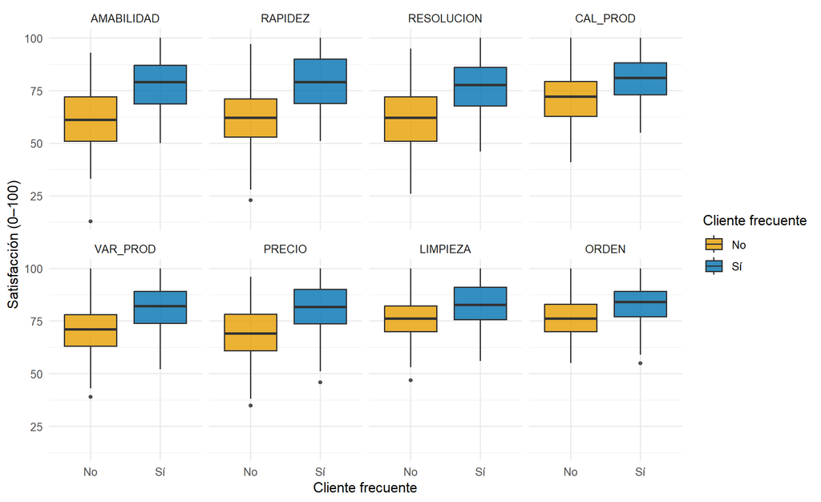

```r
datos1 %>%
  pivot_longer(cols = -CLIENTE_FRECUENTE, names_to = "Variable", values_to = "Puntaje") %>%
  mutate(Variable = factor(Variable, levels = names(datosacp))) %>%
  ggplot(aes(x = CLIENTE_FRECUENTE, y = Puntaje, fill = CLIENTE_FRECUENTE)) +
  geom_boxplot(alpha = 0.8, outlier.size = 1) +
  facet_wrap(~Variable, nrow = 2) +
  scale_fill_manual(values = c("No" = "#E69F00", "Sí" = "#0072B2")) +
  labs(x = "Cliente frecuente", y = "Satisfacción (0–100)", fill = "Cliente frecuente") +
  theme_minimal()
```

🔎 Interpretación

**Interpretación.** Las puntuaciones medias son más altas en `ORDEN` (79.7) y `LIMPIEZA` (79.2), y más bajas en `RESOLUCION` (68.8), `AMABILIDAD` (69.2) y `RAPIDEZ` (69.9): el punto débil de la experiencia es el personal. Esas tres variables son además las más dispersas (desviación estándar ≈ 15–16 puntos), mientras que `LIMPIEZA` y `ORDEN` son las más homogéneas (≈ 10 puntos). La asimetría y la curtosis son cercanas a 0 en todas las variables (distribuciones aproximadamente simétricas). Los clientes frecuentes puntúan más alto en las ocho variables, con la mayor diferencia en las tres variables del personal (≈ 78 frente a ≈ 61 puntos).

### 5.3.3 Análisis de correlación

**Matriz de correlaciones, prueba estadística y gráficos.**

```r
# Coeficientes de correlación de Pearson
kable(round(cor(datosacp), 3), caption = "Matriz de correlaciones de Pearson")
```

Matriz de correlaciones de Pearson

|  | AMABILIDAD | RAPIDEZ | RESOLUCION | CAL_PROD | VAR_PROD | PRECIO | LIMPIEZA | ORDEN |
| --- | --- | --- | --- | --- | --- | --- | --- | --- |
| AMABILIDAD | 1.000 | 0.896 | 0.902 | -0.119 | -0.084 | -0.029 | 0.008 | -0.006 |
| RAPIDEZ | 0.896 | 1.000 | 0.900 | -0.093 | -0.075 | -0.042 | 0.032 | 0.009 |
| RESOLUCION | 0.902 | 0.900 | 1.000 | -0.100 | -0.083 | -0.037 | 0.005 | -0.014 |
| CAL_PROD | -0.119 | -0.093 | -0.100 | 1.000 | 0.878 | 0.790 | 0.008 | 0.000 |
| VAR_PROD | -0.084 | -0.075 | -0.083 | 0.878 | 1.000 | 0.754 | 0.012 | -0.005 |
| PRECIO | -0.029 | -0.042 | -0.037 | 0.790 | 0.754 | 1.000 | -0.018 | -0.013 |
| LIMPIEZA | 0.008 | 0.032 | 0.005 | 0.008 | 0.012 | -0.018 | 1.000 | 0.898 |
| ORDEN | -0.006 | 0.009 | -0.014 | 0.000 | -0.005 | -0.013 | 0.898 | 1.000 |

```r
# Prueba estadística : p-valores sin ajuste (debajo de la diagonal)
# y ajustados por Holm (encima de la diagonal)
ct <- corr.test(datosacp)
kable(round(ct$p, 4), caption = "p-valores de la prueba de correlación")
```

p-valores de la prueba de correlación

|  | AMABILIDAD | RAPIDEZ | RESOLUCION | CAL_PROD | VAR_PROD | PRECIO | LIMPIEZA | ORDEN |
| --- | --- | --- | --- | --- | --- | --- | --- | --- |
| AMABILIDAD | 0.0000 | 0.0000 | 0.0000 | 0.8173 | 1.0000 | 1.0000 | 1 | 1 |
| RAPIDEZ | 0.0000 | 0.0000 | 0.0000 | 1.0000 | 1.0000 | 1.0000 | 1 | 1 |
| RESOLUCION | 0.0000 | 0.0000 | 0.0000 | 1.0000 | 1.0000 | 1.0000 | 1 | 1 |
| CAL_PROD | 0.0389 | 0.1084 | 0.0838 | 0.0000 | 0.0000 | 0.0000 | 1 | 1 |
| VAR_PROD | 0.1454 | 0.1922 | 0.1534 | 0.0000 | 0.0000 | 0.0000 | 1 | 1 |
| PRECIO | 0.6224 | 0.4734 | 0.5242 | 0.0000 | 0.0000 | 0.0000 | 1 | 1 |
| LIMPIEZA | 0.8952 | 0.5841 | 0.9328 | 0.8847 | 0.8365 | 0.7621 | 0 | 0 |
| ORDEN | 0.9232 | 0.8751 | 0.8040 | 0.9937 | 0.9338 | 0.8182 | 0 | 0 |

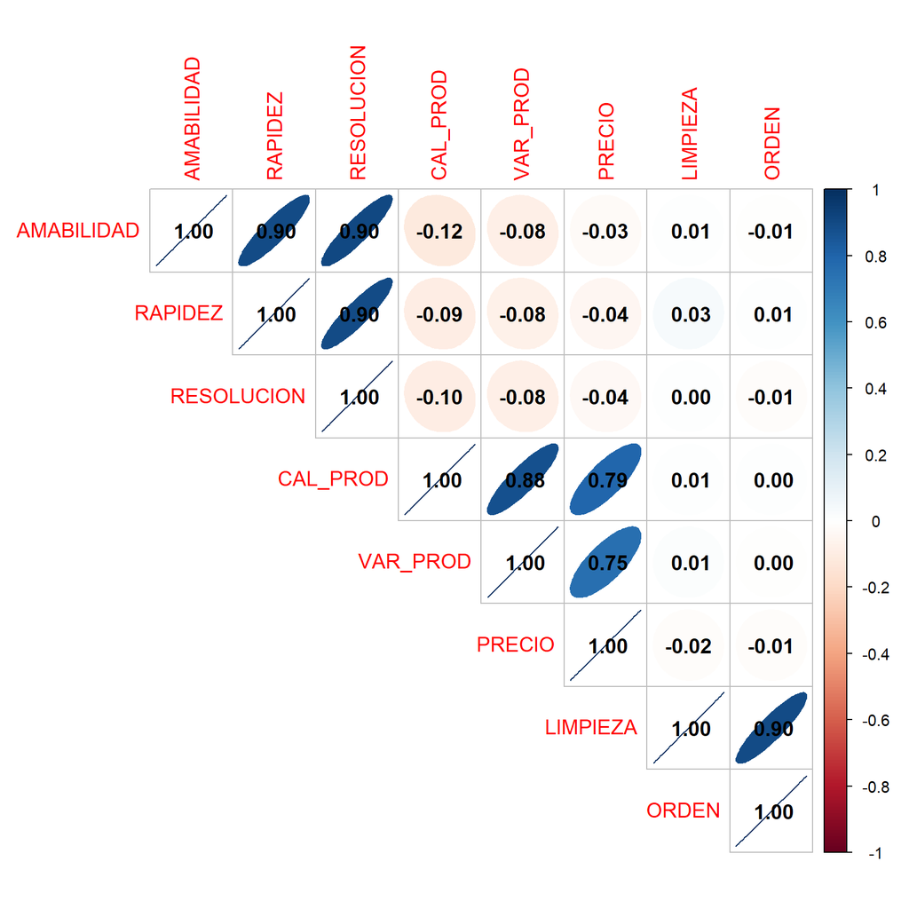

```r
# Gráfico de correlación
i <- cor(datosacp, method = "pearson")
corrplot(i, method = "ellipse", order = "original", addCoef.col = "black", type = "upper")
```

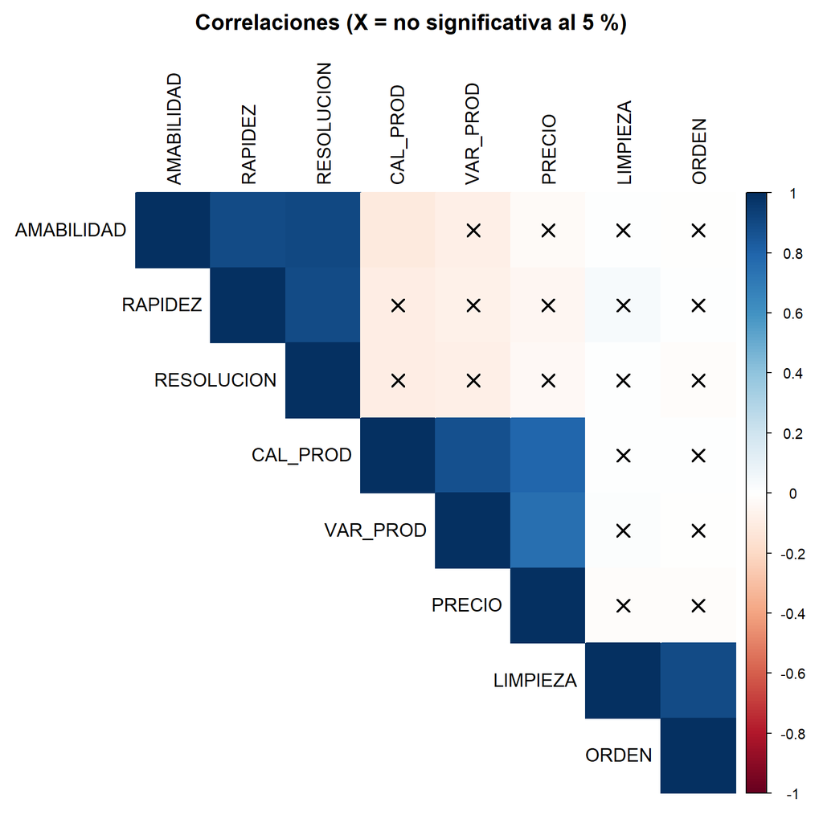

```r
# Matriz de p-valores
res1 <- cor.mtest(datosacp, conf.level = 0.95)
corrplot(i, method = "color", type = "upper", p.mat = res1$p, sig.level = 0.05,
         insig = "pch", pch.cex = 1.5, tl.col = "black",
         title = "Correlaciones (X = no significativa al 5 %)", mar = c(0, 0, 2, 0))
```

**Interpretación.** La matriz muestra tres bloques de variables muy correlacionadas entre sí y casi incorrelacionadas con los demás:

- **Personal:** `AMABILIDAD`, `RAPIDEZ` y `RESOLUCION` (r ≈ 0.90).
- **Oferta comercial:** `CAL_PROD`, `VAR_PROD` y `PRECIO` (r entre 0.75 y 0.88).
- **Instalaciones:** `LIMPIEZA` y `ORDEN` (r ≈ 0.90).

Las correlaciones entre bloques son prácticamente nulas (|r| ≤ 0.12); la única con p < 0.05 sin ajuste, `AMABILIDAD`–`CAL_PROD` (r = −0.12), deja de ser significativa al ajustar por Holm. Esta estructura anticipa tres factores latentes.

**Adecuación de los datos para el ACP .** Se aplican la prueba de esfericidad de Bartlett (H₀: la matriz de correlaciones es la identidad) y la medida de Kaiser–Meyer–Olkin (KMO).

```r
bart <- cortest.bartlett(cor(datosacp), n = nrow(datosacp))
kmo  <- KMO(datosacp)

kable(data.frame(Estadístico = c("Chi-cuadrado de Bartlett", "gl", "p-valor",
                                 "Determinante de R", "KMO global"),
                 Valor = c(round(bart$chisq, 2), bart$df, format.pval(bart$p.value, eps = 0.001),
                           signif(det(cor(datosacp)), 3), round(kmo$MSA, 3))),
      caption = "Pruebas de adecuación muestral")
```

Pruebas de adecuación muestral

| Estadístico | Valor |
| --- | --- |
| Chi-cuadrado de Bartlett | 2292.2 |
| gl | 28 |
| p-valor | < 0.001 |
| Determinante de R | 0.000428 |
| KMO global | 0.7 |

```r
kable(data.frame(Variable = names(kmo$MSAi), MSA = round(kmo$MSAi, 3)),
      row.names = FALSE, caption = "KMO individual (MSA) por variable")
```

KMO individual (MSA) por variable

| Variable | MSA |
| --- | --- |
| AMABILIDAD | 0.770 |
| RAPIDEZ | 0.786 |
| RESOLUCION | 0.777 |
| CAL_PROD | 0.675 |
| VAR_PROD | 0.717 |
| PRECIO | 0.834 |
| LIMPIEZA | 0.497 |
| ORDEN | 0.498 |

La prueba de Bartlett rechaza que la matriz de correlaciones sea la identidad (χ² = 2292.2, gl = 28, p < 0.001) y el determinante de la matriz es muy cercano a cero (0.000428), lo que confirma que existen correlaciones que el ACP puede resumir. El KMO global es 0.7 (aceptable). `LIMPIEZA` y `ORDEN` obtienen un MSA cercano a 0.50 porque solo se correlacionan entre ellas y con ninguna otra variable; esto no indica un problema de ajuste, sino que forman una dimensión propia e independiente de las demás.

### 5.3.4 Análisis de Componentes Principales

**Extracción de los componentes.** ACP sobre la matriz de correlaciones (`scale = TRUE`), conservando inicialmente los 8 componentes.

```r
acp <- dudi.pca(datosacp, scannf = FALSE, scale = TRUE, nf = ncol(datosacp))
summary(acp)
```

```
#> Class: pca dudi
#> Call: dudi.pca(df = datosacp, scale = TRUE, scannf = FALSE, nf = ncol(datosacp))
#>
#> Total inertia: 8
#>
#> Eigenvalues:
#>     Ax1     Ax2     Ax3     Ax4     Ax5
#>  2.9493  2.4681  1.8990  0.2650  0.1247
#>
#> Projected inertia (%):
#>     Ax1     Ax2     Ax3     Ax4     Ax5
#>  36.867  30.851  23.737   3.312   1.559
#>
#> Cumulative projected inertia (%):
#>     Ax1   Ax1:2   Ax1:3   Ax1:4   Ax1:5
#>   36.87   67.72   91.46   94.77   96.33
#>
#> (Only 5 dimensions (out of 8) are shown)
```

```r
# Valores propios (autovalores)
varianza <- 100 * acp$eig / sum(acp$eig)
tab_eig <- data.frame(Componente = paste0("CP", seq_along(acp$eig)),
                      Autovalor = acp$eig,
                      Varianza_pct = varianza,
                      Acumulada_pct = cumsum(varianza))
kable(tab_eig, digits = 3, caption = "Valores propios y varianza explicada")
```

Valores propios y varianza explicada

| Componente | Autovalor | Varianza_pct | Acumulada_pct |
| --- | --- | --- | --- |
| CP1 | 2.949 | 36.867 | 36.867 |
| CP2 | 2.468 | 30.851 | 67.718 |
| CP3 | 1.899 | 23.737 | 91.455 |
| CP4 | 0.265 | 3.312 | 94.767 |
| CP5 | 0.125 | 1.559 | 96.327 |
| CP6 | 0.104 | 1.297 | 97.623 |
| CP7 | 0.099 | 1.234 | 98.857 |
| CP8 | 0.091 | 1.143 | 100.000 |

```r
inertia.dudi(acp)
```

```
#> Inertia information:
#> Call: inertia.dudi(x = acp)
#>
#> Decomposition of total inertia:
#>     inertia     cum  cum(%)
#> Ax1 2.94934   2.949   36.87
#> Ax2 2.46808   5.417   67.72
#> Ax3 1.89899   7.316   91.46
#> Ax4 0.26498   7.581   94.77
#> Ax5 0.12475   7.706   96.33
#> Ax6 0.10373   7.810   97.62
#> Ax7 0.09871   7.909   98.86
#> Ax8 0.09142   8.000  100.00
```

🔎 Interpretación

Los dos primeros autovalores (2.949 y 2.468) explican 67.72 % de la varianza ; con el tercero (1.899) se llega a **91.46 %**.

**Vectores propios y correlaciones variable–componente.**

```r
# Vectores propios (coeficientes de las combinaciones lineales)
kable(round(acp$c1, 3), caption = "Vectores propios (acp$c1)")
```

Vectores propios (acp$c1)

|  | CS1 | CS2 | CS3 | CS4 | CS5 | CS6 | CS7 | CS8 |
| --- | --- | --- | --- | --- | --- | --- | --- | --- |
| AMABILIDAD | -0.481 | -0.318 | 0.011 | 0.059 | 0.361 | 0.310 | -0.074 | 0.657 |
| RAPIDEZ | -0.478 | -0.322 | -0.004 | -0.081 | -0.246 | -0.471 | -0.579 | -0.206 |
| RESOLUCION | -0.480 | -0.321 | 0.016 | -0.025 | -0.135 | 0.182 | 0.645 | -0.445 |
| CAL_PROD | 0.342 | -0.479 | -0.008 | -0.288 | -0.657 | 0.190 | 0.035 | 0.320 |
| VAR_PROD | 0.327 | -0.481 | -0.007 | -0.492 | 0.594 | -0.078 | -0.036 | -0.243 |
| PRECIO | 0.292 | -0.481 | 0.010 | 0.812 | 0.075 | -0.108 | -0.002 | -0.082 |
| LIMPIEZA | -0.013 | -0.009 | -0.707 | -0.037 | 0.026 | -0.541 | 0.355 | 0.283 |
| ORDEN | -0.006 | 0.003 | -0.707 | 0.058 | -0.019 | 0.550 | -0.338 | -0.283 |

```r
# Correlaciones entre las variables originales y las componentes principales (cargas)
kable(round(acp$co, 3), caption = "Correlaciones variable–componente (acp$co)")
```

Correlaciones variable–componente (acp$co)

|  | Comp1 | Comp2 | Comp3 | Comp4 | Comp5 | Comp6 | Comp7 | Comp8 |
| --- | --- | --- | --- | --- | --- | --- | --- | --- |
| AMABILIDAD | -0.827 | -0.499 | 0.015 | 0.030 | 0.127 | 0.100 | -0.023 | 0.199 |
| RAPIDEZ | -0.821 | -0.506 | -0.006 | -0.042 | -0.087 | -0.152 | -0.182 | -0.062 |
| RESOLUCION | -0.825 | -0.504 | 0.021 | -0.013 | -0.048 | 0.059 | 0.203 | -0.134 |
| CAL_PROD | 0.587 | -0.752 | -0.011 | -0.148 | -0.232 | 0.061 | 0.011 | 0.097 |
| VAR_PROD | 0.561 | -0.756 | -0.010 | -0.253 | 0.210 | -0.025 | -0.011 | -0.073 |
| PRECIO | 0.501 | -0.756 | 0.014 | 0.418 | 0.027 | -0.035 | -0.001 | -0.025 |
| LIMPIEZA | -0.022 | -0.014 | -0.974 | -0.019 | 0.009 | -0.174 | 0.111 | 0.086 |
| ORDEN | -0.010 | 0.004 | -0.974 | 0.030 | -0.007 | 0.177 | -0.106 | -0.086 |

```r
# Comunalidad con 3 componentes: proporción de la varianza de cada variable que retienen
kable(data.frame(Variable = rownames(acp$co),
                 Comunalidad_3CP = round(rowSums(acp$co[, 1:3]^2), 3)),
      row.names = FALSE, caption = "Comunalidad de cada variable con los 3 primeros componentes")
```

Comunalidad de cada variable con los 3 primeros componentes

| Variable | Comunalidad_3CP |
| --- | --- |
| AMABILIDAD | 0.933 |
| RAPIDEZ | 0.931 |
| RESOLUCION | 0.935 |
| CAL_PROD | 0.911 |
| VAR_PROD | 0.886 |
| PRECIO | 0.823 |
| LIMPIEZA | 0.950 |
| ORDEN | 0.949 |

#### 5.3.4.1 Cuántos componentes retener

**Gráfico de sedimentación (criterio de Kaiser).**

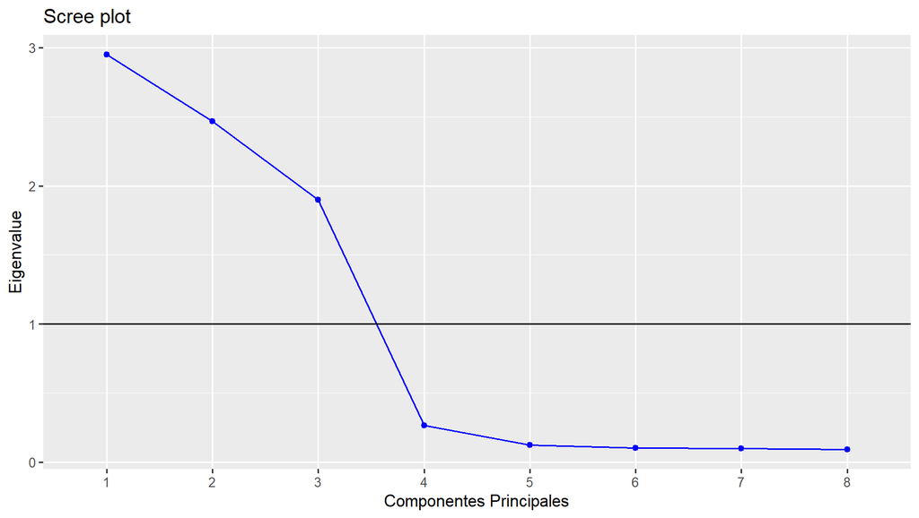

```r
a <- fviz_eig(acp, choice = 'eigenvalue', geom = "line", linecolor = 'blue',
              xlab = 'Componentes Principales') +
  geom_hline(yintercept = 1, color = 'black') +
  theme_grey()
a
```

**Método paralelo de Horn.** Un componente se retiene si su autovalor supera al que se obtendría con datos aleatorios no correlacionados del mismo tamaño.

```
#>
#> Computing: 10%  20%  30%  40%  50%  60%  70%  80%  90%  100%
```

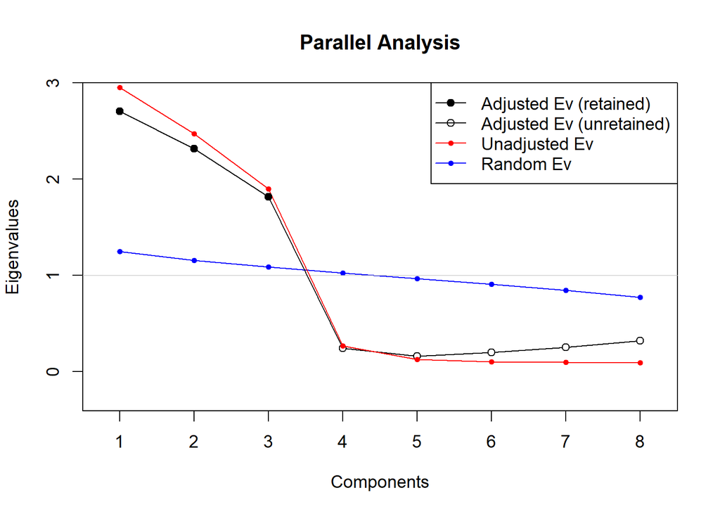

```r
paran(datosacp, iterations = 5000, graph = TRUE, color = TRUE)
```

```r
# Comprobación: autovalores observados vs. percentil 95 de autovalores de datos aleatorios
set.seed(2024)
n <- nrow(datosacp); p <- ncol(datosacp)
sim <- replicate(2000, eigen(cor(matrix(rnorm(n * p), n, p)), only.values = TRUE)$values)
tab_horn <- data.frame(Componente = paste0("CP", 1:p),
                       Observado = acp$eig,
                       Aleatorio_p95 = apply(sim, 1, quantile, probs = 0.95),
                       Retener = ifelse(acp$eig > apply(sim, 1, quantile, probs = 0.95), "Sí", "No"))
kable(tab_horn, digits = 3, caption = "Análisis paralelo de Horn (2 000 simulaciones)")
```

Análisis paralelo de Horn (2 000 simulaciones)

| Componente | Observado | Aleatorio_p95 | Retener |
| --- | --- | --- | --- |
| CP1 | 2.949 | 1.329 | Sí |
| CP2 | 2.468 | 1.214 | Sí |
| CP3 | 1.899 | 1.131 | Sí |
| CP4 | 0.265 | 1.065 | No |
| CP5 | 0.125 | 1.004 | No |
| CP6 | 0.104 | 0.950 | No |
| CP7 | 0.099 | 0.892 | No |
| CP8 | 0.091 | 0.829 | No |

🎯 Decisión

**Decisión.** Los tres criterios coinciden: (i) hay 3 autovalores mayores que 1; (ii) el gráfico de sedimentación muestra una caída brusca entre el tercer (1.90) y el cuarto autovalor (0.27); (iii) el análisis paralelo retiene 3 componentes, y (iv) estos explican 91.46 % de la varianza total. Se retienen 3 componentes principales.

#### 5.3.4.2 Representación de las variables

**Círculo de correlaciones.**

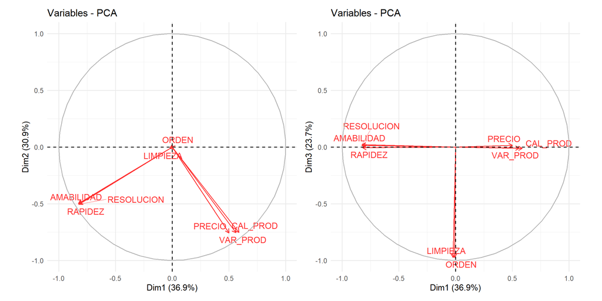

```r
b <- fviz_pca_var(acp, col.var = "#FF3030", repel = TRUE) + theme_minimal()
b13 <- fviz_pca_var(acp, axes = c(1, 3), col.var = "#FF3030", repel = TRUE) + theme_minimal()
b + b13
```

#### 5.3.4.3 Interpretación de los componentes

Con el umbral |r| ≥ 0.45 se resume la estructura retenida:

```r
cargas <- round(acp$co[, 1:3], 3)
cargas_mostrar <- apply(cargas, c(1, 2), function(v) ifelse(abs(v) >= 0.45, sprintf("%.3f", v), ""))
kable(cargas_mostrar, caption = "Cargas con |r| ≥ 0.45 (resto omitido)", align = "ccc")
```

Cargas con |r| ≥ 0.45 (resto omitido)

|  | Comp1 | Comp2 | Comp3 |
| --- | --- | --- | --- |
| AMABILIDAD | -0.827 | -0.499 |  |
| RAPIDEZ | -0.821 | -0.506 |  |
| RESOLUCION | -0.825 | -0.504 |  |
| CAL_PROD | 0.587 | -0.752 |  |
| VAR_PROD | 0.561 | -0.756 |  |
| PRECIO | 0.501 | -0.756 |  |
| LIMPIEZA |  |  | -0.974 |
| ORDEN |  |  | -0.974 |

- **CP1 (36.9 %) — “Preferencia a la atención del personal”.** Es un eje *bipolar*: `AMABILIDAD`, `RAPIDEZ` y `RESOLUCION` cargan con signo negativo (≈ −0.82) y `CAL_PROD`, `VAR_PROD` y `PRECIO` con signo positivo (0.50–0.59). Separa a los clientes que valoran más el trato de los que valoran más el producto.
- **CP2 (30.9 %) — “Satisfacción total con personal y productos”.** Las seis variables cargan con el mismo signo (−0.50 a −0.76): es un eje de satisfacción global con la atención y la oferta. Al ser el signo negativo, *las puntuaciones más negativas en CP2 indican clientes más satisfechos*.
- **CP3 (23.7 %) — “Preferencia a las instalaciones”.** `LIMPIEZA` y `ORDEN` cargan casi exclusivamente aquí (−0.974 ambas) y las demás variables no tienen relación con este eje.

Los dos primeros autovalores son parecidos (2.95 y 2.47), por lo que el plano CP1–CP2 es en la práctica un plano en el que las direcciones “personal” y “oferta” pueden girar. Como verificación se aplica una rotación varimax a los 3 componentes retenidos:

```r
pc_var <- principal(datosacp, nfactors = 3, rotate = "varimax")
kable(round(unclass(pc_var$loadings), 3), caption = "Cargas rotadas (varimax)")
```

Cargas rotadas (varimax)

|  | RC1 | RC2 | RC3 |
| --- | --- | --- | --- |
| AMABILIDAD | 0.965 | -0.042 | -0.003 |
| RAPIDEZ | 0.964 | -0.034 | 0.019 |
| RESOLUCION | 0.966 | -0.037 | -0.009 |
| CAL_PROD | -0.073 | 0.952 | 0.007 |
| VAR_PROD | -0.048 | 0.940 | 0.006 |
| PRECIO | 0.002 | 0.907 | -0.017 |
| LIMPIEZA | 0.013 | 0.003 | 0.974 |
| ORDEN | -0.007 | -0.006 | 0.974 |

```r
kable(round(pc_var$Vaccounted[1:3, ], 3), caption = "Varianza explicada tras la rotación")
```

Varianza explicada tras la rotación

|  | RC1 | RC2 | RC3 |
| --- | --- | --- | --- |
| SS loadings | 2.801 | 2.616 | 1.899 |
| Proportion Var | 0.350 | 0.327 | 0.237 |
| Cumulative Var | 0.350 | 0.677 | 0.915 |

🔎 Interpretación

Tras la rotación la estructura es nítida: RC1 = Atención del personal (cargas ≈ 0.96), RC2 = Oferta comercial (0.91–0.95) y RC3 = Instalaciones (0.97), con la misma varianza acumulada (91.5 %). Es decir, las ocho variables se resumen en tres factores latentes de la experiencia del cliente.

#### 5.3.4.4 Puntuaciones (Scores) de los clientes

**Coordenadas de los individuos y biplot.**

```r
# Scores (primeros 10 clientes)
kable(cbind(ID = datos$ID_ENCUESTA[1:10], round(acp$li[1:10, 1:3], 3)),
      caption = "Scores de los 10 primeros clientes en los 3 primeros componentes")
```

Scores de los 10 primeros clientes en los 3 primeros componentes

| ID | Axis1 | Axis2 | Axis3 |
| --- | --- | --- | --- |
| ENC-1001 | 1.307 | -0.001 | -1.724 |
| ENC-1002 | -2.516 | -0.118 | 0.852 |
| ENC-1003 | -1.295 | -0.051 | -0.661 |
| ENC-1004 | 2.524 | 0.434 | 0.154 |
| ENC-1005 | 1.146 | 0.729 | -2.280 |
| ENC-1006 | -1.085 | -2.749 | -0.587 |
| ENC-1007 | 2.842 | 3.215 | -2.850 |
| ENC-1008 | 1.245 | 0.195 | 1.139 |
| ENC-1009 | -1.132 | -2.015 | -1.138 |
| ENC-1010 | 1.324 | 1.083 | 0.246 |

```r
options(scipen = 999)
# Matriz de covarianzas de los scores: la diagonal son los autovalores y el resto es 0
kable(round(cov(acp$li), 4), caption = "Covarianza de los componentes (diagonal = autovalores)")
```

Covarianza de los componentes (diagonal = autovalores)

|  | Axis1 | Axis2 | Axis3 | Axis4 | Axis5 | Axis6 | Axis7 | Axis8 |
| --- | --- | --- | --- | --- | --- | --- | --- | --- |
| Axis1 | 2.9592 | 0.0000 | 0.0000 | 0.0000 | 0.0000 | 0.0000 | 0.000 | 0.0000 |
| Axis2 | 0.0000 | 2.4763 | 0.0000 | 0.0000 | 0.0000 | 0.0000 | 0.000 | 0.0000 |
| Axis3 | 0.0000 | 0.0000 | 1.9053 | 0.0000 | 0.0000 | 0.0000 | 0.000 | 0.0000 |
| Axis4 | 0.0000 | 0.0000 | 0.0000 | 0.2659 | 0.0000 | 0.0000 | 0.000 | 0.0000 |
| Axis5 | 0.0000 | 0.0000 | 0.0000 | 0.0000 | 0.1252 | 0.0000 | 0.000 | 0.0000 |
| Axis6 | 0.0000 | 0.0000 | 0.0000 | 0.0000 | 0.0000 | 0.1041 | 0.000 | 0.0000 |
| Axis7 | 0.0000 | 0.0000 | 0.0000 | 0.0000 | 0.0000 | 0.0000 | 0.099 | 0.0000 |
| Axis8 | 0.0000 | 0.0000 | 0.0000 | 0.0000 | 0.0000 | 0.0000 | 0.000 | 0.0917 |

```r
kable(round(cor(acp$li), 4), caption = "Correlación de los componentes (ortogonales)")
```

Correlación de los componentes (ortogonales)

|  | Axis1 | Axis2 | Axis3 | Axis4 | Axis5 | Axis6 | Axis7 | Axis8 |
| --- | --- | --- | --- | --- | --- | --- | --- | --- |
| Axis1 | 1 | 0 | 0 | 0 | 0 | 0 | 0 | 0 |
| Axis2 | 0 | 1 | 0 | 0 | 0 | 0 | 0 | 0 |
| Axis3 | 0 | 0 | 1 | 0 | 0 | 0 | 0 | 0 |
| Axis4 | 0 | 0 | 0 | 1 | 0 | 0 | 0 | 0 |
| Axis5 | 0 | 0 | 0 | 0 | 1 | 0 | 0 | 0 |
| Axis6 | 0 | 0 | 0 | 0 | 0 | 1 | 0 | 0 |
| Axis7 | 0 | 0 | 0 | 0 | 0 | 0 | 1 | 0 |
| Axis8 | 0 | 0 | 0 | 0 | 0 | 0 | 0 | 1 |

```r
kable(round(describe(acp$li)[, c("n", "mean", "sd", "min", "max", "skew", "kurtosis")], 3),
      caption = "Descriptivos de los scores")
```

Descriptivos de los scores

|  | n | mean | sd | min | max | skew | kurtosis |
| --- | --- | --- | --- | --- | --- | --- | --- |
| Axis1 | 300 | 0 | 1.720 | -4.354 | 5.463 | -0.105 | -0.152 |
| Axis2 | 300 | 0 | 1.574 | -4.279 | 5.247 | 0.217 | 0.134 |
| Axis3 | 300 | 0 | 1.380 | -2.850 | 3.863 | 0.017 | -0.534 |
| Axis4 | 300 | 0 | 0.516 | -1.372 | 1.563 | -0.070 | 0.117 |
| Axis5 | 300 | 0 | 0.354 | -1.101 | 0.991 | -0.297 | 0.054 |
| Axis6 | 300 | 0 | 0.323 | -1.156 | 0.965 | -0.058 | 0.472 |
| Axis7 | 300 | 0 | 0.315 | -1.302 | 0.869 | -0.319 | 0.724 |
| Axis8 | 300 | 0 | 0.303 | -0.935 | 0.830 | -0.044 | -0.155 |

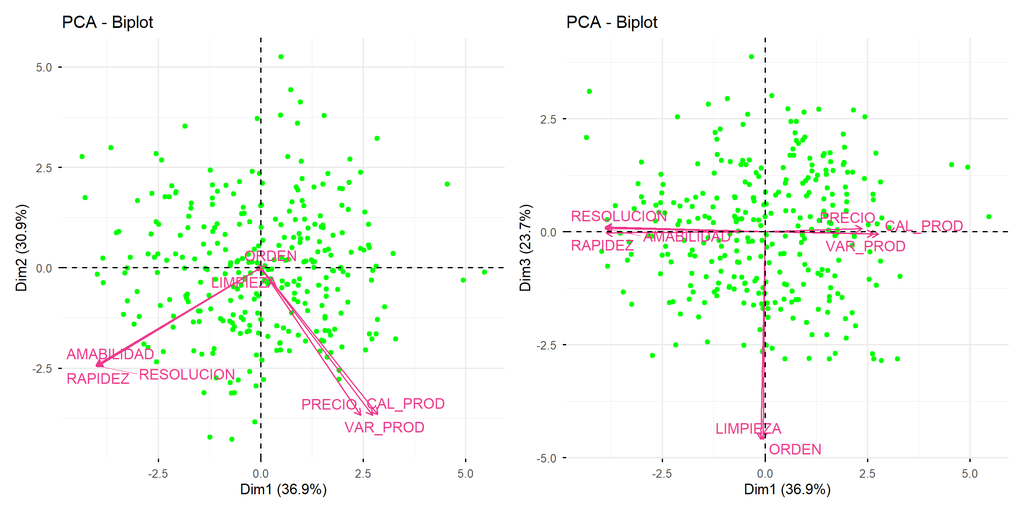

```r
# Individuos y variables sobre el primer plano (biplot)
c1 <- fviz_pca_biplot(acp, repel = TRUE, geom.ind = "point", col.var = "#EE3A8C", col.ind = "green")
c2 <- fviz_pca_biplot(acp, axes = c(1, 3), repel = TRUE, geom.ind = "point", col.var = "#EE3A8C", col.ind = "green")
c1 + c2
```

🔎 Interpretación

Los scores son incorrelacionados (covarianzas 0) y su varianza es igual al autovalor correspondiente, como exige la teoría del ACP.

### 5.3.5 Variable cualitativa: `CLIENTE_FRECUENTE`

**Proyección de la variable cualitativa ilustrativa.** La variable no interviene en el cálculo de los componentes; solo se utiliza para colorear los individuos y comparar los grupos sobre los ejes.

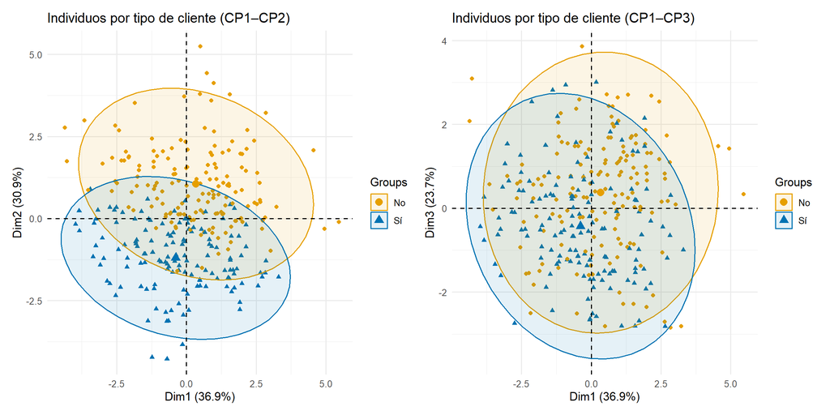

```r
grupo <- datos1$CLIENTE_FRECUENTE

p12 <- fviz_pca_ind(acp, geom.ind = "point", habillage = grupo, addEllipses = TRUE,
                    ellipse.level = 0.95, palette = c("#E69F00", "#0072B2"),
                    title = "Individuos por tipo de cliente (CP1–CP2)") + theme_minimal()
p13 <- fviz_pca_ind(acp, axes = c(1, 3), geom.ind = "point", habillage = grupo, addEllipses = TRUE,
                    ellipse.level = 0.95, palette = c("#E69F00", "#0072B2"),
                    title = "Individuos por tipo de cliente (CP1–CP3)") + theme_minimal()
p12 + p13
```

```r
scores3 <- data.frame(Grupo = grupo, acp$li[, 1:3])
kable(aggregate(. ~ Grupo, data = scores3, FUN = mean), digits = 3,
      caption = "Centroides de cada categoría en los tres primeros ejes")
```

Centroides de cada categoría en los tres primeros ejes

| Grupo | Axis1 | Axis2 | Axis3 |
| --- | --- | --- | --- |
| No | 0.338 | 1.05 | 0.374 |
| Sí | -0.387 | -1.20 | -0.428 |

```r
# Comparación de los scores entre grupos (t de Welch) y tamaño del efecto (d de Cohen)
comp <- do.call(rbind, lapply(1:3, function(k) {
  s  <- acp$li[[k]]
  tt_ <- t.test(s ~ grupo)
  d  <- (mean(s[grupo == "Sí"]) - mean(s[grupo == "No"])) /
        sqrt((var(s[grupo == "Sí"]) + var(s[grupo == "No"])) / 2)
  data.frame(Eje = paste0("CP", k), t = unname(tt_$statistic), p_valor = tt_$p.value, d_Cohen = d)
}))
kable(comp, digits = c(0, 2, 6, 2), caption = "Diferencias entre clientes frecuentes y no frecuentes")
```

Diferencias entre clientes frecuentes y no frecuentes

| Eje | t | p_valor | d_Cohen |
| --- | --- | --- | --- |
| CP1 | 3.73 | 0.000233 | -0.43 |
| CP2 | 17.82 | 0.000000 | -2.05 |
| CP3 | 5.26 | 0.000000 | -0.61 |

🔎 Interpretación

Los clientes frecuentes (`Sí`) se ubican hacia los valores negativos de CP2 y CP3, es decir, hacia mayor satisfacción. La diferencia es enorme en CP2 (t = 17.8; d ≈ −2.05), moderada en CP3 (d ≈ −0.61) y pequeña en CP1 (d ≈ −0.43). Los centroides están bien separados en el eje de satisfacción general, aunque las elipses se solapan parcialmente en los otros ejes.

### 5.3.6 Conglomerados jerárquicos sobre componentes principales

**Clasificación jerárquica (HCPC).**

```r
respca <- PCA(datosacp, scale.unit = TRUE, ncp = 8, graph = FALSE)
res.hcpc <- HCPC(respca, nb.clust = 3, graph = FALSE)

Grupos <- res.hcpc$data.clust$clust
table(Grupos)
```

```
#> Grupos
#>   1   2   3
#>  98 105  97
```

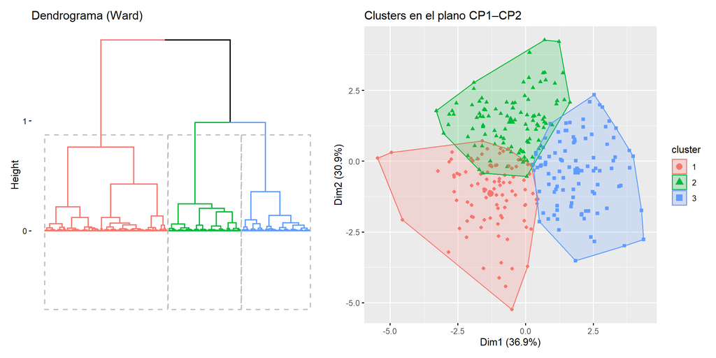

```r
d1_ <- fviz_dend(res.hcpc, show_labels = FALSE, rect = TRUE, main = "Dendrograma (Ward)")
d2_ <- fviz_cluster(res.hcpc, geom = "point", show.clust.cent = TRUE, main = "Clusters en el plano CP1–CP2")
d1_ + d2_
```

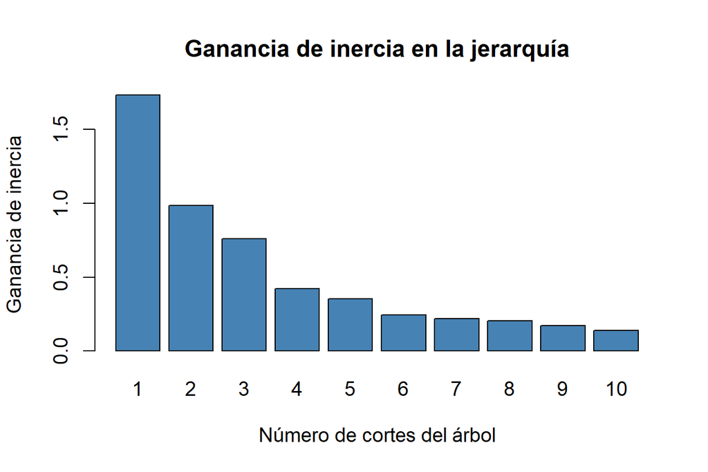

```r
barplot(res.hcpc$call$t$inert.gain[1:10], names.arg = 1:10, col = "steelblue",
        xlab = "Número de cortes del árbol", ylab = "Ganancia de inercia",
        main = "Ganancia de inercia en la jerarquía")
```

🔎 Interpretación

**Descripción de los clusters.**

```r
datosf <- cbind(datos1, Grupos)

# Perfil en base a las medias de cada variable por cluster
medias <- t(sapply(datosacp, function(v) tapply(v, Grupos, mean)))
colnames(medias) <- paste("Cluster", colnames(medias))
medias <- cbind(medias, General = colMeans(datosacp))
kable(round(medias, 2), caption = "Medias de cada variable por cluster")
```

Medias de cada variable por cluster

|  | Cluster 1 | Cluster 2 | Cluster 3 | General |
| --- | --- | --- | --- | --- |
| AMABILIDAD | 53.38 | 72.70 | 81.35 | 69.18 |
| RAPIDEZ | 54.43 | 72.84 | 82.33 | 69.89 |
| RESOLUCION | 54.02 | 71.14 | 81.22 | 68.81 |
| CAL_PROD | 74.57 | 85.69 | 64.90 | 75.33 |
| VAR_PROD | 73.39 | 85.69 | 65.75 | 75.22 |
| PRECIO | 71.83 | 86.71 | 64.66 | 74.72 |
| LIMPIEZA | 75.70 | 82.53 | 79.00 | 79.16 |
| ORDEN | 76.88 | 83.21 | 78.87 | 79.74 |

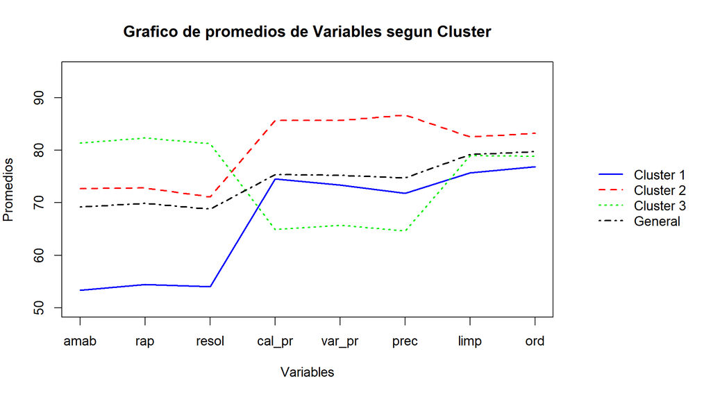

```r
layout(matrix(1:2, nrow = 1), widths = c(4, 1))
colores <- c("blue", "red", "green2", "black")
nombres <- c("Cluster 1", "Cluster 2", "Cluster 3", "General")
par(mar = c(5, 4, 4, 1))
matplot(medias,
        main = "Grafico de promedios de Variables segun Cluster",
        xlab = "Variables",
        ylab = "Promedios",
        type = "l",
        xaxt = "n",
        ylim = c(50, 95),
        col  = colores,
        lty  = 1:4,
        lwd  = 2)
axis(1, at = 1:8,
     labels = c("amab", "rap", "resol", "cal_pr", "var_pr", "prec", "limp", "ord"))
par(mar = c(0, 0, 0, 0))
plot.new()
legend("center", legend = nombres, col = colores, lty = 1:4, lwd = 2, cex = 1, bty = "n")
```

```r
layout(1)
```

```r
# Relación de los clusters con la variable ilustrativa
tab_cf <- table(Cluster = Grupos, Cliente_frecuente = datosf$CLIENTE_FRECUENTE)
kable(cbind(tab_cf, `% Sí` = round(100 * prop.table(tab_cf, 1)[, "Sí"], 1)),
      caption = "Clusters según cliente frecuente")
```

Clusters según cliente frecuente

| No | Sí | % Sí |
| --- | --- | --- |
| 98 | 0 | 0.0 |
| 11 | 94 | 89.5 |
| 51 | 46 | 47.4 |

```r
# Prueba chi-cuadrado de independencia
ch <- chisq.test(tab_cf)
ch
```

```
#>
#>  Pearson's Chi-squared test
#>
#> data:  tab_cf
#> X-squared = 163.26, df = 2, p-value < 0.00000000000000022
```

```r
# Frecuencias esperadas bajo independencia (deben ser >= 5)
round(ch$expected, 1)
```

```
#>        Cliente_frecuente
#> Cluster   No   Sí
#>       1 52.3 45.7
#>       2 56.0 49.0
#>       3 51.7 45.3
```

```r
# V de Cramér: magnitud de la asociación (0 = nula, 1 = perfecta)
V <- sqrt(unname(ch$statistic) / (sum(tab_cf) * (min(dim(tab_cf)) - 1)))
round(V, 3)
```

```
#> [1] 0.738
```

🔎 Interpretación

**Interpretación de la prueba chi-cuadrado.** Se contrasta H₀: el cluster al que pertenece un cliente es independiente de que sea cliente frecuente, frente a H₁: existe asociación entre ambas variables. El estadístico es χ² = 163.26 con gl = 2 (= (3 − 1)(2 − 1)) y p < 2.2e-16, muy inferior a α = 0.05. Por tanto se rechaza H₀: hay evidencia muy fuerte de que los clusters y la afiliación al programa de lealtad están asociados.

Esto es relevante porque los clusters se construyeron solo con las 8 variables de satisfacción, sin usar `CLIENTE_FRECUENTE`, y aun así reproducen diferencias reales entre afiliados y no afiliados: el cluster 1 (los más insatisfechos con el personal) no tiene ningún cliente frecuente (0 %), el cluster 2 (los más satisfechos) es casi todo afiliado (89.5 %) y el cluster 3 es intermedio (47.4 %). El V de Cramér es 0.74, lo que indica una asociación fuerte. La aproximación chi-cuadrado es válida porque todas las frecuencias esperadas son mayores que 5 (la menor es 45.3). La prueba muestra que existe asociación, pero no su causa: no permite saber si la afiliación genera satisfacción o si los clientes más satisfechos son los que se afilian.